#### - Students : DEBREUS Monitès & PIERRE Cassio

#### - Scheduled project review date/time:24 Otobre 2025

#### - Instructor name: JEROME Wedter & LAGUERRE Geovany

# ANALYSE ET PRÉDICTION DES MALADIES CARDIOVASCULAIRES

## Introduction

> Les maladies cardiovasculaires (MCV) figurent parmi les affections non transmissibles les plus meurtrières à l’échelle mondiale.

> Selon l'organisation mondiale de la santé, en 2019, elles ont causé près de 17,9 millions de décès. A ce jour, elles sont responsables d’environ 32 % de tous les décès dans le monde.

> Le fardeau des MCV ne cesse de croître : de 1990 à 2021, le nombre de décès cardiovasculaires est passé d’environ 12,1 millions à 20,5 millions selon les estimations de World Heart Federation, soit une hausse d’environ 60 %.

> Globalement, l'institution "American heart association" estime qu’en 2021 environ 612 millions de personnes vivaient avec une maladie cardiovasculaire.

> En Amérique, certains pays sont particulièrement affectés. Haiti se distingue par un taux de mortalité par MCV très élevé : 427,7 décès pour 100 000 habitants, le plus élevé de la région selon les estimations de la Pan American Health Organization.

> Dans le contexte haïtien, les études disponibles montrent déjà des signes alarmants : une enquête urbaine à Port-au-Prince a estimé une prévalence ajustée des MCV à ~ 14,7 % dans la population étudiée (incluant l’insuffisance cardiaque, AVC, infarctus) ; l’hypertension est le facteur de risque le plus répandu, touchant 49 % des femmes et 38 % des hommes âgés de 35 à 64 ans selon l’enquête DHS de 2017.

> De plus, même parmi les jeunes (18-30 ans), près de 23,5 % présentent une pression artérielle élevée, ce qui suggère une progression précoce du risque cardiovasculaire selon World Heart Federation.

> Ces données soulignent l’importance d’une analyse sur les maladies cardiovasculaires pour comprendre les facteurs de risque, identifier les populations les plus vulnérables, et proposer des modèles prédictifs adaptés afin de guider les politiques de prévention et d’intervention.

### Objectif général

> Analyser les facteurs de risque associés aux maladies cardiovasculaires à partir de données cliniques et comportementales issues du jeu de données Cardiovascular Disease Dataset de Kaggle, afin de développer des outils prédictifs et des visualisations permettant d’améliorer la prévention et la prise de décision en santé publique en Haïti.

### Objectifs spécifiques

> - Décrire les caractéristiques cliniques et comportementales des individus du jeu de données afin d’identifier les tendances générales liées à la santé cardiovasculaire;
> - Évaluer la relation entre certaines variables (âge, cholestérol, pression artérielle, tabagisme, activité physique, etc.) et la présence d’une maladie cardiovasculaire à l’aide d’analyses statistiques descriptives et inférentielles;
> - Construire et comparer des modèles de classification (logistic regression, random forest, etc.) pour prédire la probabilité d’apparition d’une maladie cardiovasculaire;
> - Identifier les variables les plus significatives influençant le risque cardiovasculaire à travers des techniques de feature importance et de corrélation;
> - Développer un tableau de bord interactif sur Power BI pour visualiser les résultats et faciliter l’interprétation des tendances par les acteurs du secteur de la santé.
> - Implémenter le modèle le plus performant .

### Hypothèses

> - L’âge, la pression artérielle et le cholestérol sont des facteurs fortement associés à la probabilité de développer une maladie cardiovasculaire;
> - Les modèles de machine learning peuvent prédire efficacement la probabilité d’une maladie cardiovasculaire à partir de données cliniques.

## Public cible

> Ce projet s’adresse aux acteurs impliqués dans le diagnostic, la prévention et la gestion des maladies cardiovasculaires. Il vise à fournir des informations exploitables, issues de l’analyse de données, pour appuyer la prise de décision en santé publique et améliorer la gestion clinique des patients à risque. D’une part les institutions de santé comme le MSPP et l’OPS/OMS pourront s’en servir pour cibler les campagnes de sensibilisation et de prévention. D’autre part, les professionnels de santé pourront repérer plus tôt les profils de patients à risque et adapter leurs protocoles de suivi.

> En outre, les chercheurs et étudiants en santé ou en data science y trouveront un cadre d’application concret des méthodes analytiques. Les décideurs politiques disposeront d’éléments factuels pour élaborer des politiques de santé préventive efficaces. Enfin, la population générale et les ONG pourront utiliser les visualisations et les indicateurs produits pour renforcer la sensibilisation aux risques cardiovasculaires. Ce projet établit ainsi un lien entre science des données et santé publique au service de la prévention et de la planification sanitaire en Haïti.

## Compréhension des données

> Le jeu de données utilisé dans cette étude provient de la plateforme Kaggle, sous le nom de “Cardiovascular Disease Dataset”. Il regroupe des informations cliniques et comportementales collectées sur plus de 70 000 individus, utilisées pour prédire la probabilité de survenue d’une maladie cardiovasculaire.

> Chaque observation représente un patient et est décrite par 12 variables explicatives et une variable cible (cardio) qui indique la présence (1) ou l’absence (0) d’une maladie cardiovasculaire diagnostiquée.Chaque enregistrement correspond à un individu et comprend plusieurs indicateurs médicaux, biologiques et liés au mode de vie.

> La variable cible, nommée cardio, prend deux valeurs : 0 pour les personnes considérées comme saines, 1 pour celles présentant une maladie cardiovasculaire diagnostiquée.

> Les autres variables servent à expliquer ou prédire cette cible. Elles se répartissent en deux grandes catégories : les variables categorielles encodées, ce qui rend le travail beaucoup plus abordable et les variables numériques (continue et discontinue).

> Pour les variables categorielles, on trouve:
> - Les variables cholestérol et gluc codées sous forme de chiffres pour représenter des niveaux croissants: 1 = normal,2 = élevé, 3 = très élevé.
> - La variable gender est encodée numériquement :1 = femme, 2 = homme.
> - La variable alco pour la consommation d'alcool :0 pour non buveur, 1 pour buveur).
> - La variable active pour le niveau d'activité physique des patients(0 pour inactif, 1 pour actif).
> - La variable smoke pour le statut de fumeur du patient (0 pour non-fumeur, 1 pour fumeur).

> Pour les variables numériques (continu ou discontinu):
> - La variable age du patient en jours.
> - La variable height donne la taille du patient en centimètre.
> - La variaable weight pour le poids du patient en kilogrammes.
> - La variable ap_hi pour la pression artérielle systolique.
> - La variable ap_lo pour La pression artérielle diastolique.

> Ainsi, bien que toutes les valeurs apparaissent sous forme d’entiers ou de nombres réels, plusieurs représentent en réalité des catégories ou des ordres logiques qu’il faudra interpréter correctement au moment de l’analyse.

## Méthodologie

> - Compréhension des Données
> - Data Cleaning (Nettoyage de Données)
> - Analyse descriptive
> - Analyse diagnostique
> - Analyse prédictive
> - Analyse prescriptive

## Lecture des données

```python
#importation des bibliotheques
import pandas as pd
import numpy as np
import seaborn as sns
from matplotlib import pyplot as plt
import joblib


import warnings
warnings.filterwarnings('ignore')
```

```python
# Lecture du fichier
data=pd.read_csv("cardio_train.csv",sep=';', encoding='utf-8')
#creation d'une copie
df=data.copy()
```

```python
#Affichage des 5 premières lignes
df.head()
```

|  | id | age | gender | height | weight | ap_hi | ap_lo | cholesterol | gluc | smoke | alco | active | cardio |
| --- | --- | --- | --- | --- | --- | --- | --- | --- | --- | --- | --- | --- | --- |
| 0 | 0 | 18393 | 2 | 168 | 62.0 | 110 | 80 | 1 | 1 | 0 | 0 | 1 | 0 |
| 1 | 1 | 20228 | 1 | 156 | 85.0 | 140 | 90 | 3 | 1 | 0 | 0 | 1 | 1 |
| 2 | 2 | 18857 | 1 | 165 | 64.0 | 130 | 70 | 3 | 1 | 0 | 0 | 0 | 1 |
| 3 | 3 | 17623 | 2 | 169 | 82.0 | 150 | 100 | 1 | 1 | 0 | 0 | 1 | 1 |
| 4 | 4 | 17474 | 1 | 156 | 56.0 | 100 | 60 | 1 | 1 | 0 | 0 | 0 | 0 |

```python
#verification du nombre de lignes et de colonnes
df.shape
```

```
(70000, 13)
```

```python
df.info()
```

```
<class 'pandas.core.frame.DataFrame'>
RangeIndex: 70000 entries, 0 to 69999
Data columns (total 13 columns):
 #   Column       Non-Null Count  Dtype
---  ------       --------------  -----
 0   id           70000 non-null  int64
 1   age          70000 non-null  int64
 2   gender       70000 non-null  int64
 3   height       70000 non-null  int64
 4   weight       70000 non-null  float64
 5   ap_hi        70000 non-null  int64
 6   ap_lo        70000 non-null  int64
 7   cholesterol  70000 non-null  int64
 8   gluc         70000 non-null  int64
 9   smoke        70000 non-null  int64
 10  alco         70000 non-null  int64
 11  active       70000 non-null  int64
 12  cardio       70000 non-null  int64
dtypes: float64(1), int64(12)
memory usage: 6.9 MB
```

```python
df.describe()
```

|  | id | age | gender | height | weight | ap_hi | ap_lo | cholesterol | gluc | smoke | alco | active | cardio |
| --- | --- | --- | --- | --- | --- | --- | --- | --- | --- | --- | --- | --- | --- |
| count | 70000.000000 | 70000.000000 | 70000.000000 | 70000.000000 | 70000.000000 | 70000.000000 | 70000.000000 | 70000.000000 | 70000.000000 | 70000.000000 | 70000.000000 | 70000.000000 | 70000.000000 |
| mean | 49972.419900 | 19468.865814 | 1.349571 | 164.359229 | 74.205690 | 128.817286 | 96.630414 | 1.366871 | 1.226457 | 0.088129 | 0.053771 | 0.803729 | 0.499700 |
| std | 28851.302323 | 2467.251667 | 0.476838 | 8.210126 | 14.395757 | 154.011419 | 188.472530 | 0.680250 | 0.572270 | 0.283484 | 0.225568 | 0.397179 | 0.500003 |
| min | 0.000000 | 10798.000000 | 1.000000 | 55.000000 | 10.000000 | -150.000000 | -70.000000 | 1.000000 | 1.000000 | 0.000000 | 0.000000 | 0.000000 | 0.000000 |
| 25% | 25006.750000 | 17664.000000 | 1.000000 | 159.000000 | 65.000000 | 120.000000 | 80.000000 | 1.000000 | 1.000000 | 0.000000 | 0.000000 | 1.000000 | 0.000000 |
| 50% | 50001.500000 | 19703.000000 | 1.000000 | 165.000000 | 72.000000 | 120.000000 | 80.000000 | 1.000000 | 1.000000 | 0.000000 | 0.000000 | 1.000000 | 0.000000 |
| 75% | 74889.250000 | 21327.000000 | 2.000000 | 170.000000 | 82.000000 | 140.000000 | 90.000000 | 2.000000 | 1.000000 | 0.000000 | 0.000000 | 1.000000 | 1.000000 |
| max | 99999.000000 | 23713.000000 | 2.000000 | 250.000000 | 200.000000 | 16020.000000 | 11000.000000 | 3.000000 | 3.000000 | 1.000000 | 1.000000 | 1.000000 | 1.000000 |

```python
# Coup d'oeil sur systole superieur a 200 mmHg
df[df['ap_hi'] > 200]
```

|  | id | age | gender | height | weight | ap_hi | ap_lo | cholesterol | gluc | smoke | alco | active | cardio |
| --- | --- | --- | --- | --- | --- | --- | --- | --- | --- | --- | --- | --- | --- |
| 1328 | 1863 | 21063 | 2 | 174 | 106.0 | 220 | 120 | 3 | 3 | 0 | 0 | 1 | 0 |
| 1876 | 2654 | 15116 | 1 | 160 | 60.0 | 902 | 60 | 1 | 1 | 0 | 0 | 1 | 0 |
| 2014 | 2845 | 22712 | 2 | 167 | 59.0 | 906 | 0 | 1 | 1 | 0 | 0 | 1 | 0 |
| 2142 | 3026 | 15384 | 2 | 174 | 113.0 | 210 | 1100 | 1 | 1 | 0 | 0 | 1 | 1 |
| 2278 | 3208 | 22636 | 1 | 156 | 101.0 | 220 | 110 | 1 | 2 | 0 | 0 | 0 | 1 |
| ... | ... | ... | ... | ... | ... | ... | ... | ... | ... | ... | ... | ... | ... |
| 67710 | 96686 | 19687 | 2 | 168 | 75.0 | 240 | 140 | 3 | 1 | 0 | 0 | 1 | 1 |
| 68579 | 97963 | 19769 | 2 | 171 | 71.0 | 220 | 110 | 2 | 1 | 0 | 0 | 1 | 1 |
| 68663 | 98095 | 18190 | 1 | 156 | 41.0 | 906 | 0 | 1 | 1 | 0 | 0 | 1 | 0 |
| 69329 | 99019 | 19818 | 1 | 145 | 62.0 | 240 | 130 | 1 | 1 | 0 | 0 | 0 | 1 |
| 69370 | 99089 | 14696 | 1 | 170 | 74.0 | 2000 | 100 | 2 | 1 | 0 | 0 | 1 | 1 |

100 rows × 13 columns

```python
## Coup d'oeil sur systole superieur a 120 mmHg
df[df['ap_lo'] > 120]
```

|  | id | age | gender | height | weight | ap_hi | ap_lo | cholesterol | gluc | smoke | alco | active | cardio |
| --- | --- | --- | --- | --- | --- | --- | --- | --- | --- | --- | --- | --- | --- |
| 228 | 314 | 17489 | 2 | 183 | 98.0 | 160 | 1100 | 1 | 2 | 1 | 0 | 1 | 1 |
| 241 | 334 | 21932 | 2 | 157 | 60.0 | 160 | 1000 | 2 | 1 | 0 | 0 | 0 | 1 |
| 260 | 357 | 18217 | 1 | 150 | 83.0 | 140 | 800 | 1 | 1 | 0 | 0 | 1 | 1 |
| 329 | 458 | 23407 | 1 | 176 | 63.0 | 160 | 1000 | 2 | 2 | 0 | 0 | 0 | 1 |
| 345 | 482 | 18704 | 1 | 154 | 81.0 | 140 | 1000 | 2 | 1 | 0 | 0 | 1 | 1 |
| ... | ... | ... | ... | ... | ... | ... | ... | ... | ... | ... | ... | ... | ... |
| 69771 | 99659 | 23330 | 1 | 167 | 81.0 | 160 | 1000 | 1 | 1 | 0 | 0 | 1 | 1 |
| 69872 | 99798 | 21808 | 1 | 152 | 56.0 | 160 | 1000 | 1 | 1 | 0 | 0 | 1 | 1 |
| 69878 | 99807 | 21239 | 2 | 168 | 95.0 | 160 | 1000 | 1 | 1 | 0 | 0 | 1 | 1 |
| 69885 | 99816 | 22417 | 2 | 166 | 78.0 | 170 | 1000 | 1 | 1 | 0 | 0 | 0 | 0 |
| 69967 | 99955 | 21416 | 2 | 168 | 63.0 | 140 | 1000 | 1 | 1 | 0 | 0 | 1 | 1 |

1056 rows × 13 columns

```python
# Verification si systole est superieur a diastole sur toutes les lignes
df[df['ap_hi'] > df['ap_lo']]
```

|  | id | age | gender | height | weight | ap_hi | ap_lo | cholesterol | gluc | smoke | alco | active | cardio |
| --- | --- | --- | --- | --- | --- | --- | --- | --- | --- | --- | --- | --- | --- |
| 0 | 0 | 18393 | 2 | 168 | 62.0 | 110 | 80 | 1 | 1 | 0 | 0 | 1 | 0 |
| 1 | 1 | 20228 | 1 | 156 | 85.0 | 140 | 90 | 3 | 1 | 0 | 0 | 1 | 1 |
| 2 | 2 | 18857 | 1 | 165 | 64.0 | 130 | 70 | 3 | 1 | 0 | 0 | 0 | 1 |
| 3 | 3 | 17623 | 2 | 169 | 82.0 | 150 | 100 | 1 | 1 | 0 | 0 | 1 | 1 |
| 4 | 4 | 17474 | 1 | 156 | 56.0 | 100 | 60 | 1 | 1 | 0 | 0 | 0 | 0 |
| ... | ... | ... | ... | ... | ... | ... | ... | ... | ... | ... | ... | ... | ... |
| 69995 | 99993 | 19240 | 2 | 168 | 76.0 | 120 | 80 | 1 | 1 | 1 | 0 | 1 | 0 |
| 69996 | 99995 | 22601 | 1 | 158 | 126.0 | 140 | 90 | 2 | 2 | 0 | 0 | 1 | 1 |
| 69997 | 99996 | 19066 | 2 | 183 | 105.0 | 180 | 90 | 3 | 1 | 0 | 1 | 0 | 1 |
| 69998 | 99998 | 22431 | 1 | 163 | 72.0 | 135 | 80 | 1 | 2 | 0 | 0 | 0 | 1 |
| 69999 | 99999 | 20540 | 1 | 170 | 72.0 | 120 | 80 | 2 | 1 | 0 | 0 | 1 | 0 |

68764 rows × 13 columns

```python
#Verification des valeurs manquantes
df.isnull().sum()
```

```
id             0
age            0
gender         0
height         0
weight         0
ap_hi          0
ap_lo          0
cholesterol    0
gluc           0
smoke          0
alco           0
active         0
cardio         0
dtype: int64
```

```python
#verification des doublons
print("Doublons:",df.duplicated().sum())
```

```
Doublons: 0
```

NB: Les variables categorielles ont ete deja encodees en entiers

## Data Cleaning

```python
# renommer certaines colonnes
df.rename(columns={'ap_hi':'p_systole','ap_lo':'p_diastole','gluc':'glucose','alco':'alcool'},inplace=True)
df
```

|  | id | age | gender | height | weight | p_systole | p_diastole | cholesterol | glucose | smoke | alcool | active | cardio |
| --- | --- | --- | --- | --- | --- | --- | --- | --- | --- | --- | --- | --- | --- |
| 0 | 0 | 18393 | 2 | 168 | 62.0 | 110 | 80 | 1 | 1 | 0 | 0 | 1 | 0 |
| 1 | 1 | 20228 | 1 | 156 | 85.0 | 140 | 90 | 3 | 1 | 0 | 0 | 1 | 1 |
| 2 | 2 | 18857 | 1 | 165 | 64.0 | 130 | 70 | 3 | 1 | 0 | 0 | 0 | 1 |
| 3 | 3 | 17623 | 2 | 169 | 82.0 | 150 | 100 | 1 | 1 | 0 | 0 | 1 | 1 |
| 4 | 4 | 17474 | 1 | 156 | 56.0 | 100 | 60 | 1 | 1 | 0 | 0 | 0 | 0 |
| ... | ... | ... | ... | ... | ... | ... | ... | ... | ... | ... | ... | ... | ... |
| 69995 | 99993 | 19240 | 2 | 168 | 76.0 | 120 | 80 | 1 | 1 | 1 | 0 | 1 | 0 |
| 69996 | 99995 | 22601 | 1 | 158 | 126.0 | 140 | 90 | 2 | 2 | 0 | 0 | 1 | 1 |
| 69997 | 99996 | 19066 | 2 | 183 | 105.0 | 180 | 90 | 3 | 1 | 0 | 1 | 0 | 1 |
| 69998 | 99998 | 22431 | 1 | 163 | 72.0 | 135 | 80 | 1 | 2 | 0 | 0 | 0 | 1 |
| 69999 | 99999 | 20540 | 1 | 170 | 72.0 | 120 | 80 | 2 | 1 | 0 | 0 | 1 | 0 |

70000 rows × 13 columns

```python
#Conversion des ages en annees
df['age']=(df['age']/365).round(0).astype(int)
df
```

|  | id | age | gender | height | weight | p_systole | p_diastole | cholesterol | glucose | smoke | alcool | active | cardio |
| --- | --- | --- | --- | --- | --- | --- | --- | --- | --- | --- | --- | --- | --- |
| 0 | 0 | 50 | 2 | 168 | 62.0 | 110 | 80 | 1 | 1 | 0 | 0 | 1 | 0 |
| 1 | 1 | 55 | 1 | 156 | 85.0 | 140 | 90 | 3 | 1 | 0 | 0 | 1 | 1 |
| 2 | 2 | 52 | 1 | 165 | 64.0 | 130 | 70 | 3 | 1 | 0 | 0 | 0 | 1 |
| 3 | 3 | 48 | 2 | 169 | 82.0 | 150 | 100 | 1 | 1 | 0 | 0 | 1 | 1 |
| 4 | 4 | 48 | 1 | 156 | 56.0 | 100 | 60 | 1 | 1 | 0 | 0 | 0 | 0 |
| ... | ... | ... | ... | ... | ... | ... | ... | ... | ... | ... | ... | ... | ... |
| 69995 | 99993 | 53 | 2 | 168 | 76.0 | 120 | 80 | 1 | 1 | 1 | 0 | 1 | 0 |
| 69996 | 99995 | 62 | 1 | 158 | 126.0 | 140 | 90 | 2 | 2 | 0 | 0 | 1 | 1 |
| 69997 | 99996 | 52 | 2 | 183 | 105.0 | 180 | 90 | 3 | 1 | 0 | 1 | 0 | 1 |
| 69998 | 99998 | 61 | 1 | 163 | 72.0 | 135 | 80 | 1 | 2 | 0 | 0 | 0 | 1 |
| 69999 | 99999 | 56 | 1 | 170 | 72.0 | 120 | 80 | 2 | 1 | 0 | 0 | 1 | 0 |

70000 rows × 13 columns

```python
# correction des valeurs negatives
pression=['p_systole','p_diastole']
df[pression]=df[pression].abs()
```

```python
# correction des valeurs abberantes au niveau des pressions arterielles
def corriger_valeur(x):
    if x <= 250:
        return x
    elif x <= 1700:
        return x / 10
    else:
        return x / 100
df['p_systole'] = df['p_systole'].apply(corriger_valeur)
df['p_diastole'] = df['p_diastole'].apply(corriger_valeur)
```

```python
#verification des valeurs maximales en systole
print(f"la pression systolique max est: {df['p_systole'].max()} tandisque la pression diastolique max est: {df['p_diastole'].max()}")
```

```
la pression systolique max est: 240.0 tandisque la pression diastolique max est: 190.0
```

```python
#verification des valeurs minimales en systole
print(f"la pression systolique minimale est: {df['p_systole'].min()} tandisque la pression diastolique minmale est: {df['p_diastole'].min()}")
```

```
la pression systolique minimale est: 1.0 tandisque la pression diastolique minmale est: 0.0
```

```python
#Lors de la contraction (systole), le cœur pousse le sang dans les artères, ce qui fait monter la pression.
#Quand il se relâche (diastole), la pression redescend.
#Donc, la pression systolique est toujours plus élevée que la diastolique.

#verification de cette condition
df[df['p_systole'] < df['p_diastole']]
```

|  | id | age | gender | height | weight | p_systole | p_diastole | cholesterol | glucose | smoke | alcool | active | cardio |
| --- | --- | --- | --- | --- | --- | --- | --- | --- | --- | --- | --- | --- | --- |
| 474 | 681 | 52 | 1 | 156 | 65.0 | 120.0 | 150.0 | 2 | 1 | 0 | 0 | 1 | 0 |
| 567 | 815 | 58 | 1 | 168 | 78.0 | 14.0 | 90.0 | 2 | 1 | 0 | 0 | 1 | 1 |
| 636 | 913 | 56 | 2 | 169 | 68.0 | 70.0 | 110.0 | 1 | 1 | 0 | 0 | 1 | 0 |
| 927 | 1294 | 60 | 2 | 175 | 70.0 | 14.0 | 90.0 | 3 | 1 | 0 | 0 | 1 | 1 |
| 979 | 1360 | 50 | 1 | 172 | 65.0 | 11.0 | 80.0 | 1 | 3 | 0 | 0 | 1 | 0 |
| ... | ... | ... | ... | ... | ... | ... | ... | ... | ... | ... | ... | ... | ... |
| 68742 | 98213 | 51 | 1 | 158 | 74.0 | 14.0 | 90.0 | 1 | 1 | 0 | 0 | 1 | 1 |
| 68998 | 98568 | 52 | 1 | 154 | 77.0 | 14.0 | 90.0 | 1 | 1 | 0 | 0 | 1 | 0 |
| 69137 | 98743 | 42 | 2 | 176 | 65.0 | 12.0 | 80.0 | 1 | 1 | 0 | 0 | 1 | 0 |
| 69370 | 99089 | 40 | 1 | 170 | 74.0 | 20.0 | 100.0 | 2 | 1 | 0 | 0 | 1 | 1 |
| 69549 | 99328 | 58 | 1 | 155 | 69.0 | 13.0 | 90.0 | 1 | 3 | 0 | 0 | 1 | 1 |

282 rows × 13 columns

```python
# Inverser les valeurs quand la diastole est plus grande que la systole
mask = df['p_diastole'] > df['p_systole']
df.loc[mask, ['p_systole', 'p_diastole']] = df.loc[mask, ['p_diastole', 'p_systole']].values
```

```python
# Sélectionner les lignes faibles
lignes_trop_faibles = df[(df['p_systole'] < 60) | (df['p_diastole'] < 40)]
lignes_trop_faibles
```

|  | id | age | gender | height | weight | p_systole | p_diastole | cholesterol | glucose | smoke | alcool | active | cardio |
| --- | --- | --- | --- | --- | --- | --- | --- | --- | --- | --- | --- | --- | --- |
| 418 | 594 | 46 | 1 | 157 | 72.0 | 150.0 | 30.0 | 1 | 1 | 0 | 0 | 1 | 1 |
| 567 | 815 | 58 | 1 | 168 | 78.0 | 90.0 | 14.0 | 2 | 1 | 0 | 0 | 1 | 1 |
| 927 | 1294 | 60 | 2 | 175 | 70.0 | 90.0 | 14.0 | 3 | 1 | 0 | 0 | 1 | 1 |
| 979 | 1360 | 50 | 1 | 172 | 65.0 | 80.0 | 11.0 | 1 | 3 | 0 | 0 | 1 | 0 |
| 1600 | 2260 | 53 | 1 | 165 | 66.0 | 80.0 | 12.0 | 1 | 1 | 0 | 0 | 1 | 0 |
| ... | ... | ... | ... | ... | ... | ... | ... | ... | ... | ... | ... | ... | ... |
| 68742 | 98213 | 51 | 1 | 158 | 74.0 | 90.0 | 14.0 | 1 | 1 | 0 | 0 | 1 | 1 |
| 68998 | 98568 | 52 | 1 | 154 | 77.0 | 90.0 | 14.0 | 1 | 1 | 0 | 0 | 1 | 0 |
| 69137 | 98743 | 42 | 2 | 176 | 65.0 | 80.0 | 12.0 | 1 | 1 | 0 | 0 | 1 | 0 |
| 69370 | 99089 | 40 | 1 | 170 | 74.0 | 100.0 | 20.0 | 2 | 1 | 0 | 0 | 1 | 1 |
| 69549 | 99328 | 58 | 1 | 155 | 69.0 | 90.0 | 13.0 | 1 | 3 | 0 | 0 | 1 | 1 |

238 rows × 13 columns

```python
df = df.drop(index=lignes_trop_faibles.index)
```

```python
df[df['p_systole'] > df['p_diastole']]
```

|  | id | age | gender | height | weight | p_systole | p_diastole | cholesterol | glucose | smoke | alcool | active | cardio |
| --- | --- | --- | --- | --- | --- | --- | --- | --- | --- | --- | --- | --- | --- |
| 0 | 0 | 50 | 2 | 168 | 62.0 | 110.0 | 80.0 | 1 | 1 | 0 | 0 | 1 | 0 |
| 1 | 1 | 55 | 1 | 156 | 85.0 | 140.0 | 90.0 | 3 | 1 | 0 | 0 | 1 | 1 |
| 2 | 2 | 52 | 1 | 165 | 64.0 | 130.0 | 70.0 | 3 | 1 | 0 | 0 | 0 | 1 |
| 3 | 3 | 48 | 2 | 169 | 82.0 | 150.0 | 100.0 | 1 | 1 | 0 | 0 | 1 | 1 |
| 4 | 4 | 48 | 1 | 156 | 56.0 | 100.0 | 60.0 | 1 | 1 | 0 | 0 | 0 | 0 |
| ... | ... | ... | ... | ... | ... | ... | ... | ... | ... | ... | ... | ... | ... |
| 69995 | 99993 | 53 | 2 | 168 | 76.0 | 120.0 | 80.0 | 1 | 1 | 1 | 0 | 1 | 0 |
| 69996 | 99995 | 62 | 1 | 158 | 126.0 | 140.0 | 90.0 | 2 | 2 | 0 | 0 | 1 | 1 |
| 69997 | 99996 | 52 | 2 | 183 | 105.0 | 180.0 | 90.0 | 3 | 1 | 0 | 1 | 0 | 1 |
| 69998 | 99998 | 61 | 1 | 163 | 72.0 | 135.0 | 80.0 | 1 | 2 | 0 | 0 | 0 | 1 |
| 69999 | 99999 | 56 | 1 | 170 | 72.0 | 120.0 | 80.0 | 2 | 1 | 0 | 0 | 1 | 0 |

69760 rows × 13 columns

```python
df[df['p_systole'] == df['p_diastole']]
```

|  | id | age | gender | height | weight | p_systole | p_diastole | cholesterol | glucose | smoke | alcool | active | cardio |
| --- | --- | --- | --- | --- | --- | --- | --- | --- | --- | --- | --- | --- | --- |
| 12785 | 18238 | 43 | 2 | 178 | 105.0 | 100.0 | 100.0 | 1 | 1 | 0 | 0 | 0 | 1 |
| 32190 | 45975 | 64 | 1 | 162 | 120.0 | 100.0 | 100.0 | 1 | 1 | 0 | 0 | 1 | 0 |

```python
df
```

|  | id | age | gender | height | weight | p_systole | p_diastole | cholesterol | glucose | smoke | alcool | active | cardio |
| --- | --- | --- | --- | --- | --- | --- | --- | --- | --- | --- | --- | --- | --- |
| 0 | 0 | 50 | 2 | 168 | 62.0 | 110.0 | 80.0 | 1 | 1 | 0 | 0 | 1 | 0 |
| 1 | 1 | 55 | 1 | 156 | 85.0 | 140.0 | 90.0 | 3 | 1 | 0 | 0 | 1 | 1 |
| 2 | 2 | 52 | 1 | 165 | 64.0 | 130.0 | 70.0 | 3 | 1 | 0 | 0 | 0 | 1 |
| 3 | 3 | 48 | 2 | 169 | 82.0 | 150.0 | 100.0 | 1 | 1 | 0 | 0 | 1 | 1 |
| 4 | 4 | 48 | 1 | 156 | 56.0 | 100.0 | 60.0 | 1 | 1 | 0 | 0 | 0 | 0 |
| ... | ... | ... | ... | ... | ... | ... | ... | ... | ... | ... | ... | ... | ... |
| 69995 | 99993 | 53 | 2 | 168 | 76.0 | 120.0 | 80.0 | 1 | 1 | 1 | 0 | 1 | 0 |
| 69996 | 99995 | 62 | 1 | 158 | 126.0 | 140.0 | 90.0 | 2 | 2 | 0 | 0 | 1 | 1 |
| 69997 | 99996 | 52 | 2 | 183 | 105.0 | 180.0 | 90.0 | 3 | 1 | 0 | 1 | 0 | 1 |
| 69998 | 99998 | 61 | 1 | 163 | 72.0 | 135.0 | 80.0 | 1 | 2 | 0 | 0 | 0 | 1 |
| 69999 | 99999 | 56 | 1 | 170 | 72.0 | 120.0 | 80.0 | 2 | 1 | 0 | 0 | 1 | 0 |

69762 rows × 13 columns

```python
# Enregistrement du fichier cleaned
df.to_csv('data_cleaned.csv', index=False)
```

## Exploration des donnees

```python
df.describe()
```

|  | id | age | gender | height | weight | p_systole | p_diastole | cholesterol | glucose | smoke | alcool | active | cardio |
| --- | --- | --- | --- | --- | --- | --- | --- | --- | --- | --- | --- | --- | --- |
| count | 69762.000000 | 69762.000000 | 69762.000000 | 69762.000000 | 69762.000000 | 69762.000000 | 69762.000000 | 69762.000000 | 69762.000000 | 69762.000000 | 69762.000000 | 69762.000000 | 69762.000000 |
| mean | 49974.365156 | 53.340859 | 1.349589 | 164.360583 | 74.211093 | 127.064974 | 81.587126 | 1.367263 | 1.226656 | 0.088257 | 0.053826 | 0.803776 | 0.499756 |
| std | 28848.654781 | 6.764985 | 0.476843 | 8.191651 | 14.398098 | 17.036640 | 9.730793 | 0.680589 | 0.572494 | 0.283671 | 0.225675 | 0.397143 | 0.500004 |
| min | 0.000000 | 30.000000 | 1.000000 | 55.000000 | 10.000000 | 60.000000 | 40.000000 | 1.000000 | 1.000000 | 0.000000 | 0.000000 | 0.000000 | 0.000000 |
| 25% | 25006.250000 | 48.000000 | 1.000000 | 159.000000 | 65.000000 | 120.000000 | 80.000000 | 1.000000 | 1.000000 | 0.000000 | 0.000000 | 1.000000 | 0.000000 |
| 50% | 50004.500000 | 54.000000 | 1.000000 | 165.000000 | 72.000000 | 120.000000 | 80.000000 | 1.000000 | 1.000000 | 0.000000 | 0.000000 | 1.000000 | 0.000000 |
| 75% | 74885.750000 | 58.000000 | 2.000000 | 170.000000 | 82.000000 | 140.000000 | 90.000000 | 2.000000 | 1.000000 | 0.000000 | 0.000000 | 1.000000 | 1.000000 |
| max | 99999.000000 | 65.000000 | 2.000000 | 250.000000 | 200.000000 | 240.000000 | 182.000000 | 3.000000 | 3.000000 | 1.000000 | 1.000000 | 1.000000 | 1.000000 |

```python
print(f"la pression systolique maximale est: {df['p_systole'].max()}")
print(f"la pression systolique minimale est: {df['p_systole'].min()}")
```

```
la pression systolique maximale est: 240.0
la pression systolique minimale est: 60.0
```

```python
print(f"la pression diastolique maximale est: {df['p_diastole'].max()}")
print(f"la pression diastolique minimale est: {df['p_diastole'].min()}")
```

```
la pression diastolique maximale est: 182.0
la pression diastolique minimale est: 40.0
```

```python
num_col1 = ['age', 'height', 'weight','p_systole','p_diastole']
```

```python
most_common_dict = {col: (df[col].value_counts().idxmax(), df[col].value_counts().max())
                    for col in num_col1}
```

```python
print(f" L'age, la hauteur et le poids les plus reccurents sont: {most_common_dict}")
```

```
 L'age, la hauteur et le poids les plus reccurents sont: {'age': (56, 6005), 'height': (165, 5827), 'weight': (65.0, 3837), 'p_systole': (120.0, 27714), 'p_diastole': (80.0, 34804)}
```

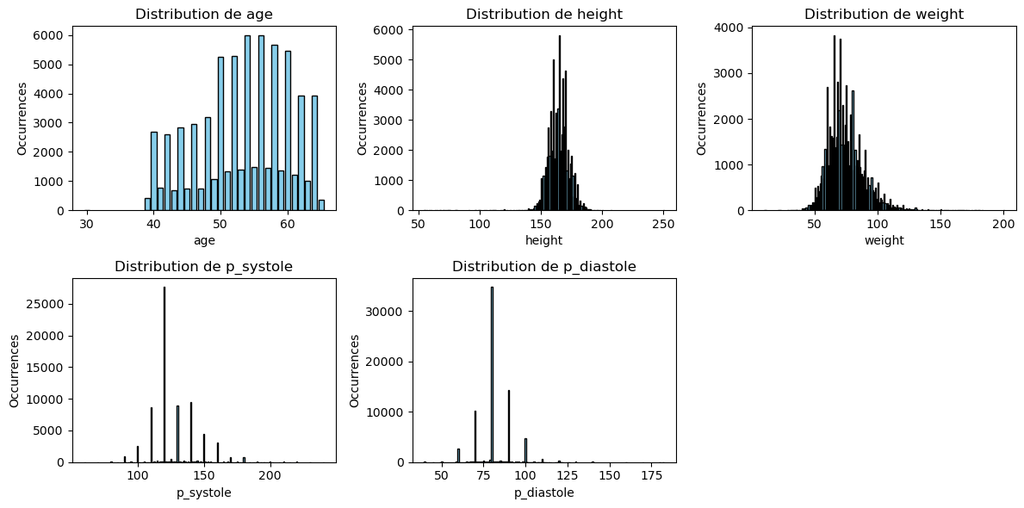

```python
#Distribution de certaines variables numeriques
plt.figure(figsize=(12,6))

for i, col in enumerate(num_col1, 1):
    plt.subplot(2, 3, i)
    counts = df[col].value_counts().sort_index()
    plt.bar(counts.index, counts.values, color='skyblue', edgecolor='black')
    plt.title(f"Distribution de {col}")
    plt.xlabel(col)
    plt.ylabel("Occurrences")

plt.tight_layout()
plt.show();
```

#### Observation

> Ces graphiques montrent qu’une grande majorité de personnes sont âgées de 50 à 60 ans au niveau de l’échantillon analysé et leurs hauteurs sont concentrées entre 160 à 175 cm. La majorité des personnes ont un poids compris entre 60 à 80 kg avec quelques cas isolés pouvant aller jusqu’à 200kg. La pression systolique des personnes de l’échantillon est concentrée autour de 100 à 150 mmHg et autour de 60 à 100 mmHg pour la pression diastolique. Ces données ont montré que dans certains cas, la pression est éstimée à plus de 200 mmHg et plus de 125 mmHg, ces chiffres signalent des cas critiques de pression artérielle pouvant compromettre la santé des patients et conduire au développement des maladies cardiovasculaires.

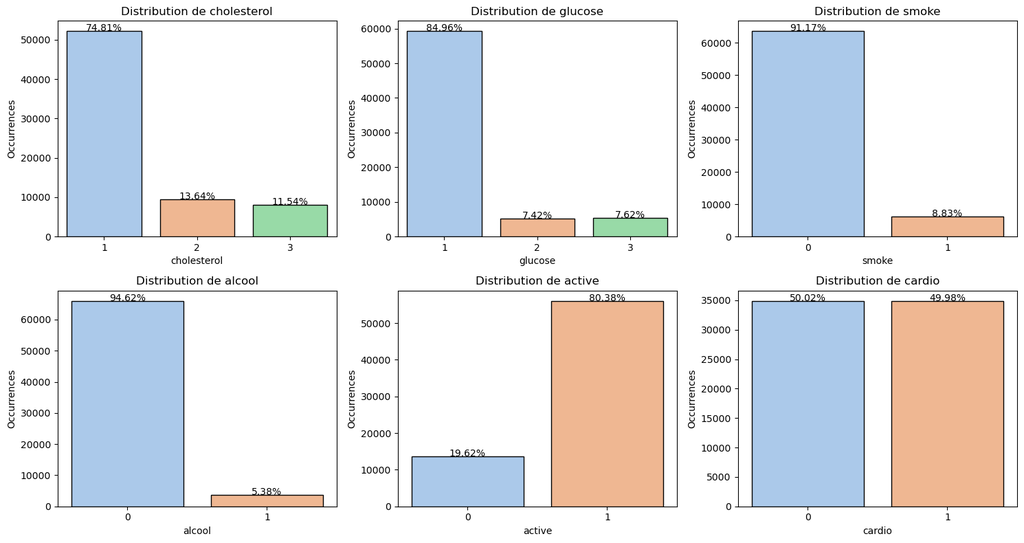

```python
# Distribution des variables catégorielles avec pourcentages
cat_cols = ['cholesterol', 'glucose', 'smoke', 'alcool', 'active', 'cardio']
fig, axes = plt.subplots(2, 3, figsize=(15, 8))
axes = axes.flatten()

for ax, col in zip(axes, cat_cols):
    # Countplot
    sns.countplot(data=df, x=col, ax=ax, palette='pastel', edgecolor='black')

    # Calcul des pourcentages
    total = len(df)
    for p in ax.patches:
        height = p.get_height()
        percentage = f'{100 * height / total:.2f}%'
        ax.text(p.get_x() + p.get_width()/2., height + 0.5, percentage, ha="center", fontsize=10)

    # Titres et axes
    ax.set_title(f"Distribution de {col}")
    ax.set_xlabel(col)
    ax.set_ylabel("Occurrences")

plt.tight_layout()
plt.show()
```

#### Observation

> Pour la variable cholestérol qui se répartit en trois niveaux : 1 pour niveau normal, 2 pour niveau élevé et 3 pour niveau très élevé, la grande majorité des personnes ont un niveau de cholestérol normal, soit 74.81% contre respectivement 13.64% et 11.54% pour le niveau élevé et très élevé ;

> La grande majorité des personnes ont un niveau de glucose normal, soit 84.96% contre 7.42% et 7.62% pour le niveau élevé et très élevé ;

> Les non-fumeurs représentent 91.17% et les fumeurs sont : 8.83% ;

> 94.62% des personnes ne consomment pas d’alcool contre 5.38% ;

> 80.38% des personnes exercent des activités physiques contre 19.62% ;

> 49.98% des personnes ont des maladies cardiovasculaires contre 50.02% saines .

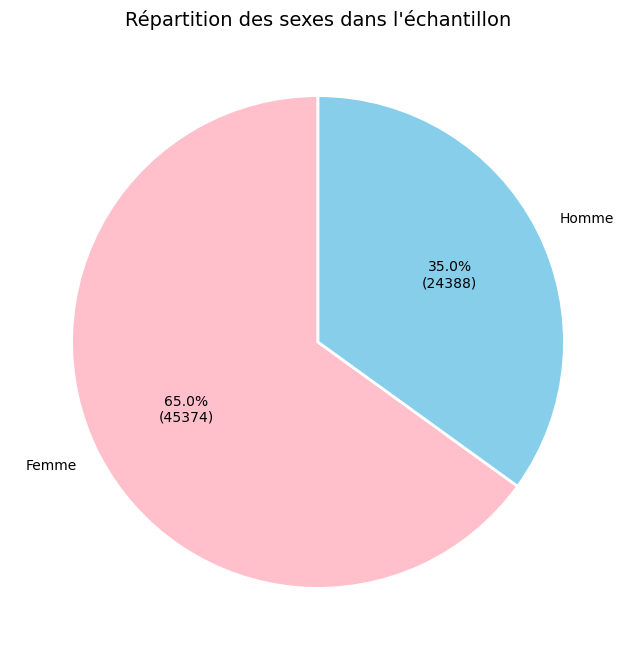

```python
# Le nombre de femmes et d'hommes
gender_counts = df['gender'].value_counts()

# Couleurs et étiquettes
colors = ['pink', 'skyblue']
labels = ['Femme', 'Homme']

# Diagramme circulaire
plt.figure(figsize=(8, 8))
plt.pie(
    gender_counts,
    labels=labels,
    colors=colors,
    autopct=lambda p: f'{p:.1f}%\n({int(p * gender_counts.sum() / 100)})',  # % + nombre absolu
    startangle=90,
    wedgeprops={'edgecolor': 'white', 'linewidth': 2}
)

plt.title("Répartition des sexes dans l'échantillon", fontsize=14)
plt.show();
```

### Observation

> Ce graphique démontre que ces données ont été collectées majoritairement sur des femmes, qui représente 65% de l’échantillon contre 35% pour les hommes.

### Age et cardio

```python
# Groupement par 'age' et 'cardio'
age_cardio_grouped = df.groupby(['age', 'cardio']).size().unstack(fill_value=0)
age_cardio_grouped['Total']=age_cardio_grouped.sum(axis=1)
#calcul des pourcentage
age_cardio_grouped['AVC']=(age_cardio_grouped[1]/age_cardio_grouped['Total'])*100
age_cardio_grouped['sans_AVC']=(age_cardio_grouped[0]/age_cardio_grouped['Total'])*100
```

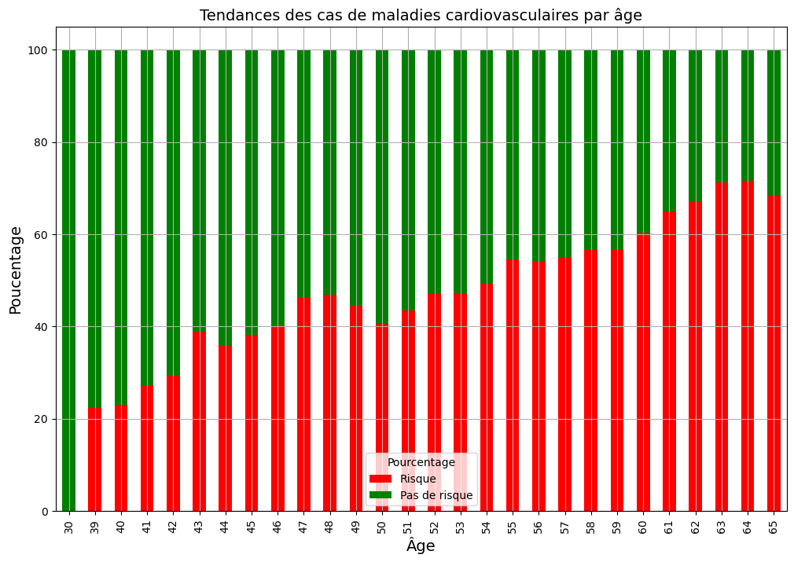

```python
# Graphique en ligne
plt.figure(figsize=(12, 8))
ax=age_cardio_grouped[['AVC','sans_AVC']].plot(kind='bar',stacked=True, ax=plt.gca(), color=['red', 'green'])
plt.title('Tendances des cas de maladies cardiovasculaires par âge', fontsize=14)
plt.xlabel('Âge', fontsize=14)
plt.ylabel('Poucentage', fontsize=14)
plt.legend(title='Pourcentage', labels=['Risque','Pas de risque'])
plt.grid()
plt.show();
```

#### Observations:

> Les résultats de l’analyse de ce jeu de données ont démontré que les maladies cardiovasculaires augmentent avec l’âge. Ces maladies surviennent après les 30 ans, et qu’après 45 ans, plus de 40 % des personnes sont atteintes de maladies cardiovasculaires avec un pic autour de 63-64 ans (plus de 70%), comme c’est indiqué sur le graphique ci-dessus. C'est une période à haut risque qui mérite une attention médicale accrue et une prévention ciblée.

### Genre et cardio

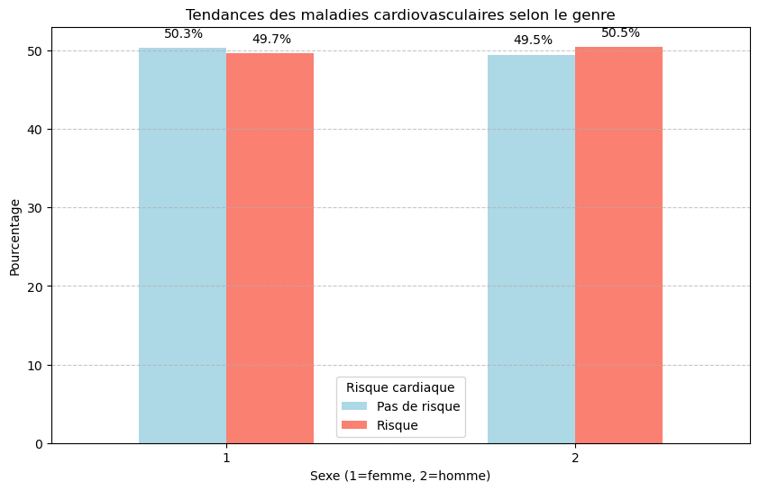

```python
percent = (
    df.groupby(['gender', 'cardio'])
      .size()
      .groupby(level=0)
      .apply(lambda x: 100 * x / x.sum())
      .unstack(fill_value=0)
)

percent.index = percent.index.get_level_values(0)

# l’ordre des sexes (1=femme, 2=homme)
percent = percent.reindex([1, 2])


# Graphique à barres côte-à-côte
ax = percent.plot(kind='bar', figsize=(10,6), color=['lightblue', 'salmon'])
plt.title('Tendances des maladies cardiovasculaires selon le genre')
plt.xlabel('Sexe (1=femme, 2=homme)')
plt.ylabel('Pourcentage')
plt.xticks(rotation=0)
plt.legend(title='Risque cardiaque', labels=['Pas de risque', 'Risque'])
plt.grid(axis='y', linestyle='--', alpha=0.7)

#Ajout des pourcentages sur les barres
for i, gender in enumerate(percent.index):
    for j, cardio in enumerate(percent.columns):
        ax.text(i + j*0.25 - 0.12, percent.loc[gender, cardio] + 1,  # position x et y
                f"{percent.loc[gender, cardio]:.1f}%", ha='center', va='bottom', fontsize=10)

plt.show();
```

#### Observations:

> Pour les deux groupes (hommes et femmes), la différence est relativement faible. En ce qui concerne les femmes, 50.3% sont saines contre 49.7% malades. Chez les hommes, c’est 49.5% sains contre 50.5% malades. Étant donné que l’échantillon analysé est majoritairement composé de femmes, on s’en suit pour dire que sur la base de ces résultats, il y a beaucoup plus de femmes qui souffrent de maladies cardiovasculaires. Cependant du point de vue de proportionnalité, les maladies cardiovasculaires sont légèrement plus élevés chez les hommes (50.5% contre 49.7%) comme illustré sur le graphique ci-dessus. Ce qui nous rapproche de la littérature médicale qui affirme qu’il y aurait une prédominance pour les maladies cardiaques chez les hommes par rapport aux femmes.

### Cholestérol et cardio

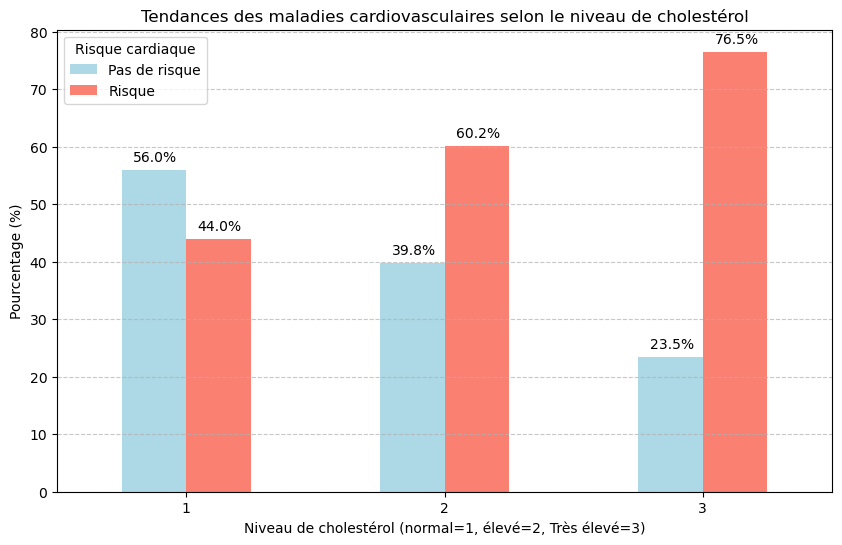

```python
# Groupement par 'cholesterol' et 'cardio'
cholesterol_cardio_grouped = df.groupby(['cholesterol', 'cardio']).size().unstack(fill_value=0)

# Calculer le pourcentage par niveau de cholestérol
cholesterol_percent = cholesterol_cardio_grouped.div(cholesterol_cardio_grouped.sum(axis=1), axis=0) * 100

# Graphique à barres côte-à-côte
ax = cholesterol_percent.plot(kind='bar', figsize=(10,6), color=['lightblue', 'salmon'])

plt.title('Tendances des maladies cardiovasculaires selon le niveau de cholestérol')
plt.xlabel('Niveau de cholestérol (normal=1, élevé=2, Très élevé=3)')
plt.ylabel('Pourcentage (%)')
plt.xticks(rotation=0)
plt.legend(title='Risque cardiaque', labels=['Pas de risque', 'Risque'])
plt.grid(axis='y', linestyle='--', alpha=0.7)

# Ajouter les pourcentages sur les barres
for i, chol in enumerate(cholesterol_percent.index):
    for j, cardio in enumerate(cholesterol_percent.columns):
        ax.text(i + j*0.25 - 0.12, cholesterol_percent.loc[chol, cardio] + 1,  # position x et y
                f"{cholesterol_percent.loc[chol, cardio]:.1f}%", ha='center', va='bottom', fontsize=10)

plt.show();
```

#### Observations:

> L’analyse diagnostique montre qu’il y a de liens entre le niveau de cholestérol des personnes enquêtés (faible, élevé ou très élevé) et les maladies cardiovasculaires. C'est à dire que le risque augmenterait tant que le niveau de cholestérol augmente. Pour les personnes qui ont un taux de cholestérol normal, 56% sont saines contre 44% à risque, alors que parmi celles qui ont des taux de cholestérol très élevé, 76.5% sont malades contre 23.5% sains. ce qui voudrait dire qu’un taux de cholestérol normal ne vous écarterait pas tout à fait des maladies cardiovasculaires, mais il diminuerait le risque d’être atteint.

### Activité et cardio

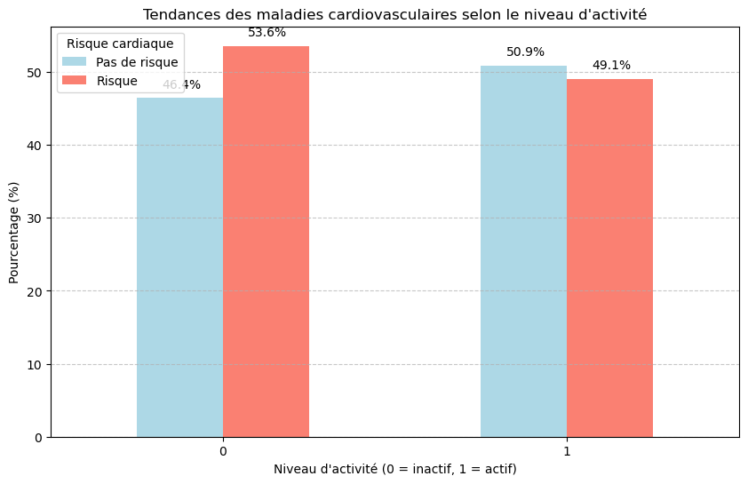

```python
# Groupement par 'active' et 'cardio'
active_cardio_grouped = df.groupby(['active', 'cardio']).size().unstack(fill_value=0)

# Calculer le pourcentage par niveau d'activité
active_percent = active_cardio_grouped.div(active_cardio_grouped.sum(axis=1), axis=0) * 100

# Graphique à barres côte-à-côte
ax = active_percent.plot(kind='bar', figsize=(10,6), color=['lightblue', 'salmon'])

plt.title('Tendances des maladies cardiovasculaires selon le niveau d\'activité')
plt.xlabel('Niveau d\'activité (0 = inactif, 1 = actif)')
plt.ylabel('Pourcentage (%)')
plt.xticks(rotation=0)
plt.legend(title='Risque cardiaque', labels=['Pas de risque', 'Risque'])
plt.grid(axis='y', linestyle='--', alpha=0.7)

# Ajouter les pourcentages sur les barres
for i, act in enumerate(active_percent.index):
    for j, cardio in enumerate(active_percent.columns):
        ax.text(i + j*0.25 - 0.12, active_percent.loc[act, cardio] + 1,
                f"{active_percent.loc[act, cardio]:.1f}%", ha='center', va='bottom', fontsize=10)

plt.show();
```

#### Observation

> Comparativement aux personnes inactives, les personnes qui effectuent des exercices physiques sont légèrement moins sujettes aux maladies cardiovasculaires. Le graphique 7 suivant montre que chez les personnes inactives, 53.6% sont à malades contre 46.4% qui ne le sont pas. Or, chez les personnes actives, 49.1% sont à risques contre 50,9% sans risques. Quoique la différence est légère, mais plus vous pratiquez des exercices physiques modérées moins vous êtes exposés aux risques des maladies cardiocasculaires, semble-t-il.

### Alcool - Tabagisme et cardio

```python
# pourcentage fumeur ayant une maladie cardiovasculaire ou non
percent_smoke = (
    df.groupby(['smoke', 'cardio'])
      .size()
      .groupby(level=0)
      .apply(lambda x: 100 * x / x.sum())
      .unstack(fill_value=0)
)
percent_smoke.index = ['Non fumeur', 'Fumeur']

# Pourcentage alcoolique ayant une maladie cardiovasculaire ou non
percent_alco = (
    df.groupby(['alcool', 'cardio'])
      .size()
      .groupby(level=0)
      .apply(lambda x: 100 * x / x.sum())
      .unstack(fill_value=0)
)

# Renommer les index
percent_alco.index = ['Non alcool', 'Alcool']
```

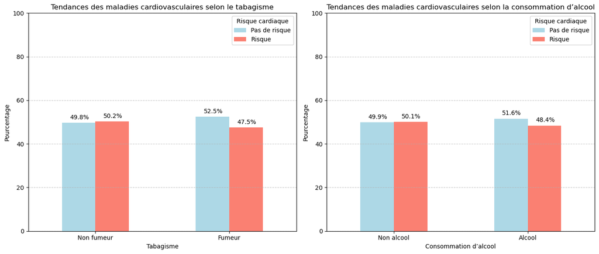

```python
# Graphique Tabac
fig, axes = plt.subplots(1, 2, figsize=(14,6))

ax1 = percent_smoke.plot(kind='bar', ax=axes[0], color=['lightblue', 'salmon'])
ax1.set_title('Tendances des maladies cardiovasculaires selon le tabagisme')
ax1.set_xlabel('Tabagisme')
ax1.set_ylabel('Pourcentage')
ax1.set_ylim(0, 100)
ax1.legend(title='Risque cardiaque', labels=['Pas de risque', 'Risque'])
ax1.grid(axis='y', linestyle='--', alpha=0.7)
ax1.set_xticklabels(['Non fumeur', 'Fumeur'], rotation=0)

# Pourcentages sur les barres
for i, cat in enumerate(percent_smoke.index):
    for j, cardio in enumerate(percent_smoke.columns):
        ax1.text(i + j*0.25 - 0.12, percent_smoke.loc[cat, cardio] + 1,
                 f"{percent_smoke.loc[cat, cardio]:.1f}%", ha='center', va='bottom', fontsize=10)

# Graphique Alcool
ax2 = percent_alco.plot(kind='bar', ax=axes[1], color=['lightblue', 'salmon'])
ax2.set_title('Tendances des maladies cardiovasculaires selon la consommation d’alcool')
ax2.set_xlabel('Consommation d’alcool')
ax2.set_ylabel('Pourcentage')
ax2.set_ylim(0, 100)
ax2.legend(title='Risque cardiaque', labels=['Pas de risque', 'Risque'])
ax2.grid(axis='y', linestyle='--', alpha=0.7)
ax2.set_xticklabels(['Non alcool', 'Alcool'], rotation=0)

# Ajout des pourcentages
for i, cat in enumerate(percent_alco.index):
    for j, cardio in enumerate(percent_alco.columns):
        ax2.text(i + j*0.25 - 0.12, percent_alco.loc[cat, cardio] + 1,
                 f"{percent_alco.loc[cat, cardio]:.1f}%", ha='center', va='bottom', fontsize=10)

# Ajustement global
plt.tight_layout()
plt.show();
```

#### Observations:

> Les données ont montré que le tabagisme à lui seul et l'alcool ne sont pas des facteurs discriminant pour les maladies cardiovasculaires. Les graphiques suivants ont montré que chez les personnes qui ne fument pas 50,2% ont des maladies cardiovasculaires contre 49.8% Cette difference est encore plus marquée chez les fumeurs, car 47.5% ont des maladies cardiovasculaires contre 52.5% sains. La tendance est la même pour l’alcool, parmis ceux qui boivent il y a 48.4% qui en souffrent contre 51.6%.

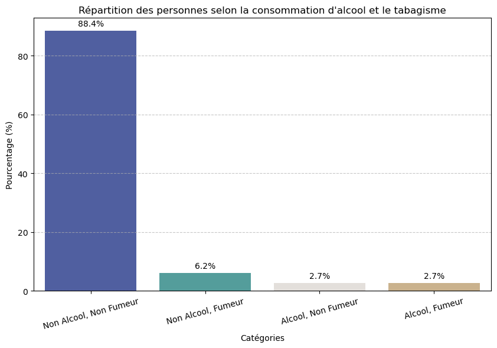

```python
# Regrouper les données et compter les effectif
grouped = df.groupby(['alcool', 'smoke']).size().reset_index(name='count')

# Calculer le pourcentage
total = grouped['count'].sum()
grouped['percentage'] = (grouped['count'] / total) * 100

# Créer des étiquettes
grouped['label'] = grouped.apply(lambda x:
    f"{'Alcool' if x.alcool else 'Non Alcool'}, {'Fumeur' if x.smoke else 'Non Fumeur'}", axis=1)

# Graphique
plt.figure(figsize=(10, 6))
ax = sns.barplot(x='label', y='percentage', data=grouped, palette=['#4357AD', '#48A9A6', '#E4DFDA', '#D4B483'])

plt.title("Répartition des personnes selon la consommation d'alcool et le tabagisme")
plt.xlabel("Catégories")
plt.ylabel("Pourcentage (%)")
plt.grid(axis='y', linestyle='--', alpha=0.7)
plt.xticks(rotation=15)

# Ajouter les pourcentages sur les barres
for p in ax.patches:
    height = p.get_height()
    ax.text(p.get_x() + p.get_width()/2, height + 1, f"{height:.1f}%", ha='center', va='bottom', fontsize=10)

plt.show();
```

### Pression artérielle et cardio

```python
df = df.reset_index(drop=True)

# Intervalle
df['p_systole_bin'] = pd.cut(
    df['p_systole'],
    bins=[60, 110, 130, 160,250],
    labels=['60-110', '110-130', '130-160', '160-250'],
    include_lowest=True
)
df['p_diastole_bin'] = pd.cut(
    df['p_diastole'],
    bins=[40, 60, 90, 120, 200],
    labels=['40-60', '60-90', '90-120', '120-200'],
    include_lowest=True
)

# % cardio=0 et cardio=1
systole_percent = (
    df.groupby(['p_systole_bin', 'cardio'])
    .size()
    .groupby(level=0)
    .apply(lambda x: 100 * x / x.sum())
    .unstack(fill_value=0)
)

systole_percent.index = systole_percent.index.get_level_values(0)
#  % cardio=0 et cardio=1
diastole_percent = (
    df.groupby(['p_diastole_bin', 'cardio'])
    .size()
    .groupby(level=0)
    .apply(lambda x: 100 * x / x.sum())
    .unstack(fill_value=0)
)
diastole_percent.index = diastole_percent.index.get_level_values(0)
```

```python
diastole_percent
```

| cardio p_diastole_bin | 0 | 1 |
| --- | --- | --- |
| 40-60 | 75.272983 | 24.727017 |
| 60-90 | 52.168135 | 47.831865 |
| 90-120 | 16.182432 | 83.817568 |
| 120-200 | 11.538462 | 88.461538 |

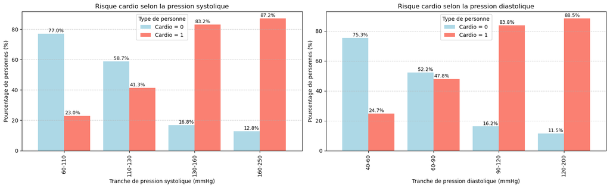

```python
fig, axes = plt.subplots(1, 2, figsize=(16, 5))

# Graphique SYSTOLIQUE
systole_percent.plot(
    kind='bar',
    ax=axes[0],
    color=['lightblue', 'salmon'],
    width=0.8
)
axes[0].set_title("Risque cardio selon la pression systolique")
axes[0].set_xlabel("Tranche de pression systolique (mmHg)")
axes[0].set_ylabel("Pourcentage de personnes (%)")
axes[0].legend(['Cardio = 0', 'Cardio = 1'], title="Type de personne")
axes[0].grid(axis='y', linestyle='--', alpha=0.6)

# Ajout des pourcentages sur les barres
for i, bin_label in enumerate(systole_percent.index):
    for j, cardio_label in enumerate(systole_percent.columns):
        val = systole_percent.loc[bin_label, cardio_label]
        axes[0].text(i + (j - 0.5) * 0.25, val + 1, f"{val:.1f}%", ha='center', fontsize=9)


# Graphique DIASTOLIQUE
diastole_percent.plot(
    kind='bar',
    ax=axes[1],
    color=['lightblue', 'salmon'],
    width=0.8
)
axes[1].set_title("Risque cardio selon la pression diastolique")
axes[1].set_xlabel("Tranche de pression diastolique (mmHg)")
axes[1].set_ylabel("Pourcentage de personnes (%)")
axes[1].legend(['Cardio = 0', 'Cardio = 1'], title="Type de personne")
axes[1].grid(axis='y', linestyle='--', alpha=0.6)

for i, bin_label in enumerate(diastole_percent.index):
    for j, cardio_label in enumerate(diastole_percent.columns):
        val = diastole_percent.loc[bin_label, cardio_label]
        axes[1].text(i + (j - 0.5) * 0.25, val + 1, f"{val:.1f}%", ha='center', fontsize=9)

plt.tight_layout()
plt.show();
```

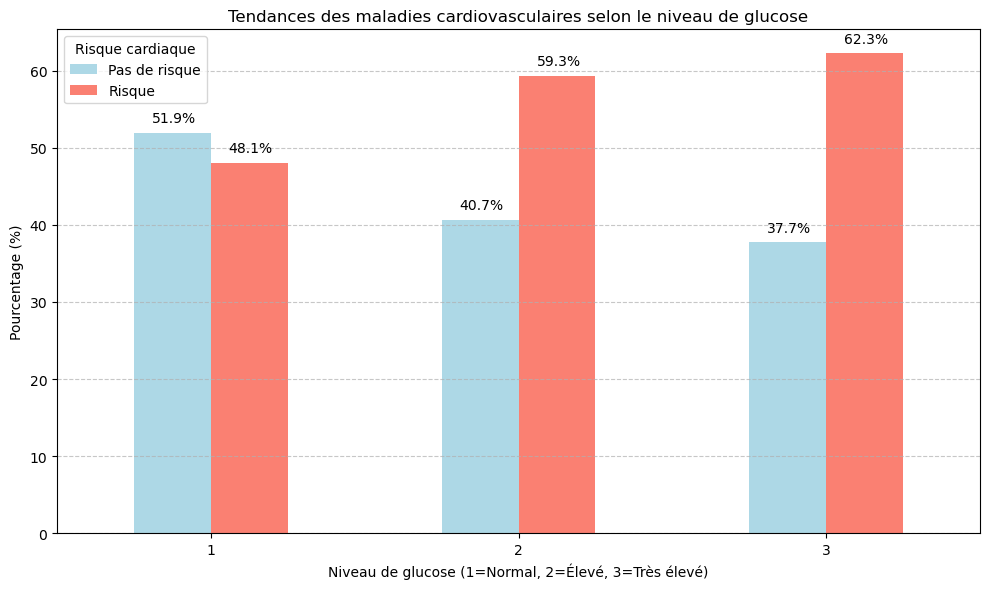

```python
# Groupement par 'glucose' et 'cardio'
glucose_cardio_grouped = df.groupby(['glucose', 'cardio']).size().unstack(fill_value=0)

# Calcul du pourcentage par catégorie de glucose
glucose_percent = glucose_cardio_grouped.div(glucose_cardio_grouped.sum(axis=1), axis=0) * 100

# Graphique à barres côte-à-côte
ax = glucose_percent.plot(kind='bar', figsize=(10,6), color=['lightblue', 'salmon'])

plt.title('Tendances des maladies cardiovasculaires selon le niveau de glucose')
plt.xlabel('Niveau de glucose (1=Normal, 2=Élevé, 3=Très élevé)')
plt.ylabel('Pourcentage (%)')
plt.xticks(rotation=0)
plt.legend(title='Risque cardiaque', labels=['Pas de risque', 'Risque'])
plt.grid(axis='y', linestyle='--', alpha=0.7)

# Ajouter les pourcentages sur les barres
for i, glu in enumerate(glucose_percent.index):
    for j, cardio in enumerate(glucose_percent.columns):
        ax.text(i + j*0.25 - 0.12, glucose_percent.loc[glu, cardio] + 1,
                f"{glucose_percent.loc[glu, cardio]:.1f}%",
                ha='center', va='bottom', fontsize=10)

plt.tight_layout()
plt.show();
```

#### Observation

> Les personnes qui ont des taux de glucose anormale presentent sont celles qui souffent le plus des maladies cardiovasculaires.

### Matrice de corrélation

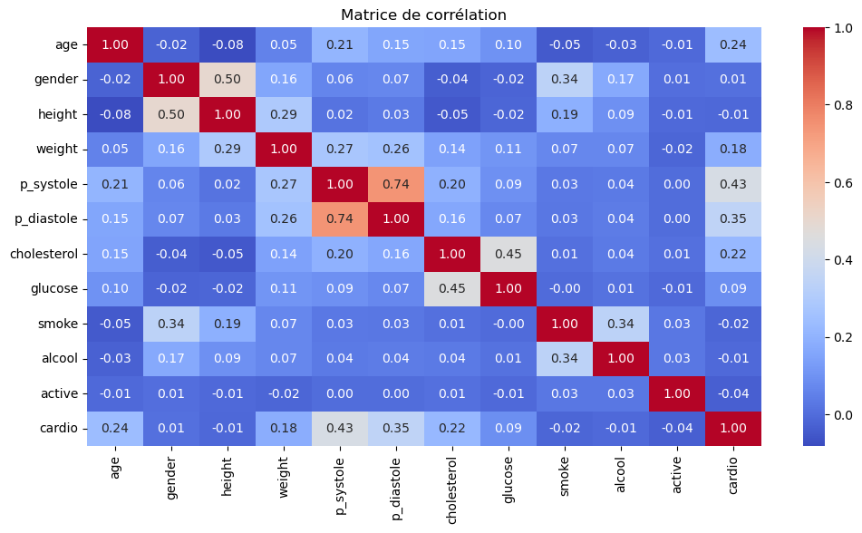

```python
# Corrélation entre toutes les variables
correl=df.drop(['id','p_systole_bin','p_diastole_bin'], axis=1)
# figure
plt.figure(figsize=(12,6))
sns.heatmap(correl.corr(), annot=True, cmap='coolwarm', fmt=".2f")
plt.title("Matrice de corrélation")
plt.show();
```

#### Observation

> Selon la matrice, on voit que les maladies cardiovasculaires sont beaucoup plus correlées à la tension arterielle systolique (0.43), diastolique (0.35), l'age (0.24), le cholesterol (0.22) et le poids (0.18) . Inversement, les risques de maladies cardiovasculaires sont plus ou moins négativement correlées avec les personnes actives (-0.04).

```python
# Introduction de l'indice de masse corporelle (Corpulence)
df['imc']=(df['weight']/(df['height']/100)**2)
```

```python
# Categorisation de l'imc
def imc_category(imc):
    if imc < 18.5:
        return 0  # insuffisance pondérale
    elif ((imc>=18.5) & (imc <= 24.9)):
        return 1  # normal
    elif ((imc>24.9) & (imc <=29.9)):
        return 2  # surpoids
    else:
        return 3  # obésité

df['imc_cat'] = df['imc'].apply(imc_category)
df
```

|  | id | age | gender | height | weight | p_systole | p_diastole | cholesterol | glucose | smoke | alcool | active | cardio | p_systole_bin | p_diastole_bin | imc | imc_cat |
| --- | --- | --- | --- | --- | --- | --- | --- | --- | --- | --- | --- | --- | --- | --- | --- | --- | --- |
| 0 | 0 | 50 | 2 | 168 | 62.0 | 110.0 | 80.0 | 1 | 1 | 0 | 0 | 1 | 0 | 60-110 | 60-90 | 21.967120 | 1 |
| 1 | 1 | 55 | 1 | 156 | 85.0 | 140.0 | 90.0 | 3 | 1 | 0 | 0 | 1 | 1 | 130-160 | 60-90 | 34.927679 | 3 |
| 2 | 2 | 52 | 1 | 165 | 64.0 | 130.0 | 70.0 | 3 | 1 | 0 | 0 | 0 | 1 | 110-130 | 60-90 | 23.507805 | 1 |
| 3 | 3 | 48 | 2 | 169 | 82.0 | 150.0 | 100.0 | 1 | 1 | 0 | 0 | 1 | 1 | 130-160 | 90-120 | 28.710479 | 2 |
| 4 | 4 | 48 | 1 | 156 | 56.0 | 100.0 | 60.0 | 1 | 1 | 0 | 0 | 0 | 0 | 60-110 | 40-60 | 23.011177 | 1 |
| ... | ... | ... | ... | ... | ... | ... | ... | ... | ... | ... | ... | ... | ... | ... | ... | ... | ... |
| 69757 | 99993 | 53 | 2 | 168 | 76.0 | 120.0 | 80.0 | 1 | 1 | 1 | 0 | 1 | 0 | 110-130 | 60-90 | 26.927438 | 2 |
| 69758 | 99995 | 62 | 1 | 158 | 126.0 | 140.0 | 90.0 | 2 | 2 | 0 | 0 | 1 | 1 | 130-160 | 60-90 | 50.472681 | 3 |
| 69759 | 99996 | 52 | 2 | 183 | 105.0 | 180.0 | 90.0 | 3 | 1 | 0 | 1 | 0 | 1 | 160-250 | 60-90 | 31.353579 | 3 |
| 69760 | 99998 | 61 | 1 | 163 | 72.0 | 135.0 | 80.0 | 1 | 2 | 0 | 0 | 0 | 1 | 130-160 | 60-90 | 27.099251 | 2 |
| 69761 | 99999 | 56 | 1 | 170 | 72.0 | 120.0 | 80.0 | 2 | 1 | 0 | 0 | 1 | 0 | 110-130 | 60-90 | 24.913495 | 2 |

69762 rows × 17 columns

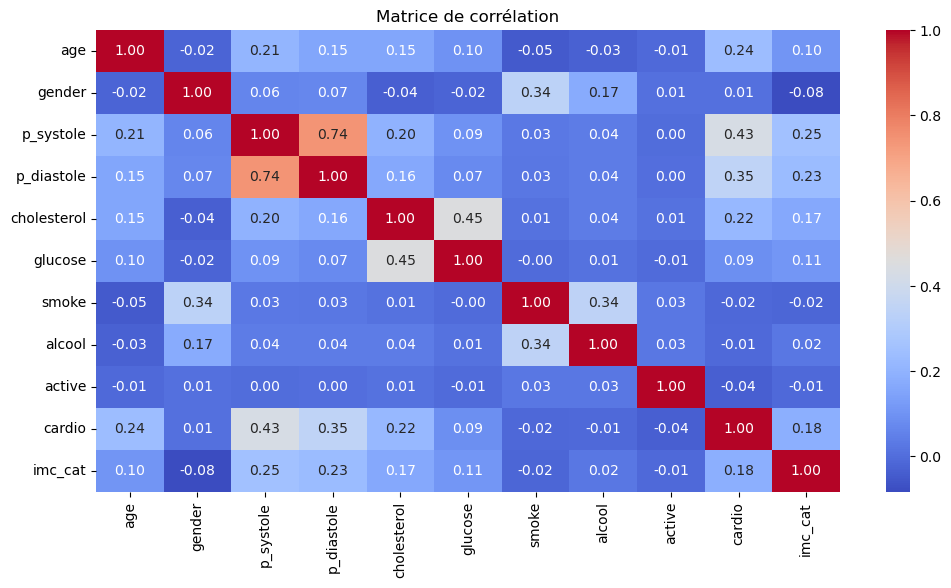

```python
# Correlation entre toutes les variables
correl2=df.drop(['id','height','weight','p_systole_bin','p_diastole_bin','imc'], axis=1)
# figure
plt.figure(figsize=(12,6))
sns.heatmap(correl2.corr(), annot=True, cmap='coolwarm', fmt=".2f")
plt.title("Matrice de corrélation")
plt.show();
```

### Observation

> Après avoir introduit l'indice de masse corporelle pour substituer le poids et la hauteur, on voit qu'il n'y a pas de changement dans la corrélation avec le poids. Cet indice tient compte du poids et de la hauteur à la fois, c'est un bon indicateur pour la suite du travail.

### Discussion sur l'analyse exploratoire

> L’analyse exploratoire du jeu de données révèle qu’il s’agit d’un échantillon composé de personnes âgées d’au moins 30 ans, majoritairement féminine, avec un âge maximal de 65 ans. Les individus mesurent au minimum 55 cm pour un poids d’au moins 10 kg. Les valeurs les plus récurrentes observées sont l’âge de 56 ans, la taille de 165 cm et le poids de 65 kg.

> La plupart des participants présentent des niveaux de cholestérol et de glucose normaux. Globalement, les individus ne fument pas, consomment peu ou pas d’alcool et sont généralement actifs physiquement. Malgré ce mode de vie, les données montrent un équilibre presque parfait entre les personnes atteintes de maladies cardiovasculaires et celles qui ne le sont pas (49.98% de cas de maladies). C’est pourquoi on a été intrigué par l’idée d’identifier les variables qui expliquent mieux la présence des maladies cardiovasculaires.

> Sur le plan biologique, les graphiques mettent en évidence un lien entre les niveaux de cholestérol et de glucose et le risque cardiovasculaire. Les personnes ayant une pression artérielle systolique supérieure à 120 mmHg, une pression diastolique dépassant 80 mmHg sont les plus exposées aux maladies cardiovasculaires. À l’inverse, les personnes physiquement actives semblent légèrement mieux protégées.

> De plus, l’âge apparaît comme un facteur déterminant : le risque cardiovasculaire augmente nettement à partir de 45 ans pour dépasser les 40 %, atteignant un pic critique autour de 63 à 64 ans, soit un pourcentage de risque de plus de 70 %. Cette tranche d’âge constitue donc une période à haut risque nécessitant une attention médicale accrue.

## Modélisation

```python
# Importer les bibliotheques necessaires
from sklearn.feature_selection import SelectKBest, f_regression
from sklearn.model_selection import train_test_split, cross_val_score, GridSearchCV
from sklearn.linear_model import LogisticRegression
from sklearn.ensemble import RandomForestClassifier
from sklearn.metrics import mean_squared_error, r2_score, accuracy_score, classification_report, confusion_matrix,roc_auc_score, precision_recall_curve,recall_score,precision_score
from sklearn.neighbors import KNeighborsClassifier
from sklearn.preprocessing import StandardScaler
from sklearn.tree import DecisionTreeClassifier, plot_tree
from xgboost import XGBClassifier
from sklearn.ensemble import GradientBoostingClassifier
from sklearn.svm import SVC
from sklearn.pipeline import Pipeline
```

```python
# Enlèvement des colonnes de données non nécessaires pour a modélisation
df.drop(columns=['p_diastole_bin','p_systole_bin','id','height','weight','imc'], inplace=True)
df
```

|  | age | gender | p_systole | p_diastole | cholesterol | glucose | smoke | alcool | active | cardio | imc_cat |
| --- | --- | --- | --- | --- | --- | --- | --- | --- | --- | --- | --- |
| 0 | 50 | 2 | 110.0 | 80.0 | 1 | 1 | 0 | 0 | 1 | 0 | 1 |
| 1 | 55 | 1 | 140.0 | 90.0 | 3 | 1 | 0 | 0 | 1 | 1 | 3 |
| 2 | 52 | 1 | 130.0 | 70.0 | 3 | 1 | 0 | 0 | 0 | 1 | 1 |
| 3 | 48 | 2 | 150.0 | 100.0 | 1 | 1 | 0 | 0 | 1 | 1 | 2 |
| 4 | 48 | 1 | 100.0 | 60.0 | 1 | 1 | 0 | 0 | 0 | 0 | 1 |
| ... | ... | ... | ... | ... | ... | ... | ... | ... | ... | ... | ... |
| 69757 | 53 | 2 | 120.0 | 80.0 | 1 | 1 | 1 | 0 | 1 | 0 | 2 |
| 69758 | 62 | 1 | 140.0 | 90.0 | 2 | 2 | 0 | 0 | 1 | 1 | 3 |
| 69759 | 52 | 2 | 180.0 | 90.0 | 3 | 1 | 0 | 1 | 0 | 1 | 3 |
| 69760 | 61 | 1 | 135.0 | 80.0 | 1 | 2 | 0 | 0 | 0 | 1 | 2 |
| 69761 | 56 | 1 | 120.0 | 80.0 | 2 | 1 | 0 | 0 | 1 | 0 | 2 |

69762 rows × 11 columns

```python
#Séparation des données
X = df.drop('cardio', axis=1)  # Variables independantes
y = df['cardio']  # Variable cible

# Split train_test
X_train, X_test, y_train, y_test = train_test_split(X, y, test_size=0.2, random_state=42)
```

### 1- Modelisation initiale

#### a - Regression Logistique

```python
# Entraînement du modèle
model_log=LogisticRegression(max_iter=1000)
model_log.fit(X_train,y_train)

# Prediction du modèle
y_pred=model_log.predict(X_test)

# Évaluation du modèle
print("Accuracy :", accuracy_score(y_test, y_pred))
print("\nMatrice de confusion :\n", confusion_matrix(y_test, y_pred))
print("\nRapport de classification :\n", classification_report(y_test, y_pred))

#Importance des variables
#importances = pd.Series(model_log.feature_importances_, index=X.columns).sort_values(ascending=False)
#print("\nImportance des features :\n", importances)
```

```
Accuracy : 0.7308822475453307

Matrice de confusion :
 [[5468 1546]
 [2209 4730]]

Rapport de classification :
               precision    recall  f1-score   support

           0       0.71      0.78      0.74      7014
           1       0.75      0.68      0.72      6939

    accuracy                           0.73     13953
   macro avg       0.73      0.73      0.73     13953
weighted avg       0.73      0.73      0.73     13953
```

#### Observation

> Le modèle de régression logistique présente une performance globale de 73,1 %. Ce qui veut dire que le modèle a raison environ 73 fois sur 100.

> Avec une précision de 0,71 et un rappel de 0,78 pour les non malades contre 0,75 et 0,68 pour les malades, le modèle tend à sous-détecter certains cas de maladie cardiovasculaire, ce qui reste une limite dans le contexte médical. Néanmoins, l’équilibre entre les classes et les scores moyens de recall et de f1-score (0,73) démontrent une bonne cohérence interne.

> Ce pourcentage de recall 0.68 pour la classe 1, met l’accent sur le fait que sur 100 malades réels, notre modèle en détecte environ 68 et en rate 32. C’est un résultat moyen, pas tout à fait satisfaisant en médecine, car rater un malade peut avoir de graves conséquences. Il est préférable de rater un non malade que de rater un malade. Donc, on peut maximiser le recall pour ne rater aucun malade.

#### b- Decision Tree

```python
#Création et entraînement du modèle
dt_model = DecisionTreeClassifier(random_state=42)  # limiter la profondeur pour éviter l'overfitting
dt_model.fit(X_train, y_train)

# Prédictions
y_pred = dt_model.predict(X_test)

# Évaluation
print("Accuracy :", accuracy_score(y_test, y_pred))
print("\nMatrice de confusion :\n", confusion_matrix(y_test, y_pred))
print("\nRapport de classification :\n", classification_report(y_test, y_pred))

# Importance des variables
importances = pd.Series(dt_model.feature_importances_, index=X.columns).sort_values(ascending=False)
print("\nImportance des features :\n", importances)
```

```
Accuracy : 0.6804271482835232

Matrice de confusion :
 [[5298 1716]
 [2743 4196]]

Rapport de classification :
               precision    recall  f1-score   support

           0       0.66      0.76      0.70      7014
           1       0.71      0.60      0.65      6939

    accuracy                           0.68     13953
   macro avg       0.68      0.68      0.68     13953
weighted avg       0.68      0.68      0.68     13953


Importance des features :
 p_systole      0.446289
age            0.195241
p_diastole     0.085741
imc_cat        0.064952
cholesterol    0.060773
gender         0.038102
glucose        0.035516
active         0.030489
smoke          0.021733
alcool         0.021164
dtype: float64
```

#### Observation

> Le modèle Decision Tree atteint une exactitude globale de 68 %, ce qui traduit une performance moyenne, inférieure a celle de la régression logistique.

> Il présente une meilleure aptitude à identifier les individus sans maladie cardiovasculaire que ceux atteints. En effet, la matrice de confusion indique 5298 vrais négatifs contre 4196 vrais positifs, mais aussi 1716 faux positifs et 2743 faux négatifs, soulignant une tendance à manquer plusieurs cas de “cardio”.

> Le rappel de 0,60 pour la classe 1 montre que le modèle détecte seulement 60 % des patients réellement malades, tandis que la précision de 0,71 pour cette même classe indique qu’il est plutôt fiable lorsqu’il prédit un cas positif.

> L’analyse des importances de variables révèle que la pression systolique est de loin le facteur le plus influent (0,45), suivie de l’âge (0,20) et de la pression diastolique (0,09). Les variables liées au mode de vie (tabac, alcool, activité physique) ont un impact plus faible, traduisant un poids moindre dans la décision du modèle.

#### c- Random Forest

```python
# Entraînement du modèle
model_rf=RandomForestClassifier(n_estimators=100, random_state=42)
model_rf.fit(X_train,y_train)

#Prediction du modèle
y_pred=model_rf.predict(X_test)

# Évaluation du modèle
print("Accuracy :", accuracy_score(y_test, y_pred))
print("\nMatrice de confusion :\n", confusion_matrix(y_test, y_pred))
print("\nRapport de classification :\n", classification_report(y_test, y_pred))

# Importance des variables
importances = pd.Series(model_rf.feature_importances_, index=X.columns).sort_values(ascending=False)
print("\nImportance des features :\n", importances)
```

```
Accuracy : 0.7061563821400416

Matrice de confusion :
 [[5187 1827]
 [2273 4666]]

Rapport de classification :
               precision    recall  f1-score   support

           0       0.70      0.74      0.72      7014
           1       0.72      0.67      0.69      6939

    accuracy                           0.71     13953
   macro avg       0.71      0.71      0.71     13953
weighted avg       0.71      0.71      0.71     13953


Importance des features :
 p_systole      0.327236
age            0.266599
p_diastole     0.155512
cholesterol    0.068955
imc_cat        0.059594
glucose        0.035071
gender         0.030083
active         0.025036
smoke          0.017218
alcool         0.014696
dtype: float64
```

#### Observation

> Le modèle Random Forest atteint une exactitude globale de 71 %, marquant une amélioration notable par rapport au Decision Tree précédent.

> La matrice de confusion indique 5187 vrais négatifs et 4666 vrais positifs, contre 1827 faux positifs et 2273 faux négatifs, montrant un certain équilibre entre les deux classes.

> Le rappel pour la classe “cardio” est de 0,67, tandis que la précision atteint 0,72, traduisant une performance considérable pour la détection des patients réellement atteints.

> L’analyse des importances de variables met en évidence que la pression systolique (0,33), l’âge (0,27) et la pression diastolique (0,16) sont les facteurs les plus influents dans la prédiction, confirmant leur rôle clé dans le risque cardiovasculaire. Le cholestérol, l’IMC et le glucose conservent une contribution secondaire, tandis que les facteurs comportementaux (tabac, alcool, activité physique) demeurent faiblement explicatifs.

#### d- XGBoost

```python
# Entraînement du modèle
model_xgb= XGBClassifier(use_label_encoder=False, eval_metric='logloss', random_state=42)
model_xgb.fit(X_train,y_train)

#Prediction
y_pred=model_xgb.predict(X_test)

# Évaluation du modèle
print("Accuracy :", accuracy_score(y_test, y_pred))
print("\nMatrice de confusion :\n", confusion_matrix(y_test, y_pred))
print("\nRapport de classification :\n", classification_report(y_test, y_pred))

# importance des variables
importances = pd.Series(model_xgb.feature_importances_, index=X.columns).sort_values(ascending=False)
print("\nImportance des features :\n", importances)
```

```
Accuracy : 0.7321722926969111

Matrice de confusion :
 [[5448 1566]
 [2171 4768]]

Rapport de classification :
               precision    recall  f1-score   support

           0       0.72      0.78      0.74      7014
           1       0.75      0.69      0.72      6939

    accuracy                           0.73     13953
   macro avg       0.73      0.73      0.73     13953
weighted avg       0.73      0.73      0.73     13953


Importance des features :
 p_systole      0.494300
cholesterol    0.156690
age            0.084968
active         0.049165
smoke          0.041261
glucose        0.040735
imc_cat        0.038965
alcool         0.037369
p_diastole     0.028729
gender         0.027817
dtype: float32
```

#### Observation

> La matrice de confusion indique que sur 7014 individus sans maladie cardiovasculaire, 5448 sont correctement identifiés (TN) tandis que 1566 sont faussement classés comme atteints (FP). Du côté des 6939 patients réellement cardio, 4768 sont correctement détectés (TP) contre 2171 faux négatifs (FN).

> Avec une précision de 0,72 et un rappel de 0,78 pour les non malades contre 0,75 et 0,69 pour les malades, le modèle tend à sous-détecter certains cas de maladie cardiovasculaire, ce qui reste une limite dans le contexte médical.

> L’analyse des importances de variables révèle que la pression systolique domine largement l’explication du modèle avec un poids de 0,49, suivie du cholestérol (0,16) et de l’âge (0,09). Les autres facteurs : tels que l’activité physique, le tabac, l’IMC et le glucose contribuent de façon plus modérée, tandis que la pression diastolique et le genre ont un impact marginal.

#### e- KNN

```python
#  Identification des colonnes continues
continuous_cols = ['age', 'p_systole', 'p_diastole']
encodee_cols = [col for col in X.columns if col not in continuous_cols]

# Normalisation des colonnes continues uniquement
scaler = StandardScaler()
X_train_cont = scaler.fit_transform(X_train[continuous_cols])
X_test_cont = scaler.transform(X_test[continuous_cols])

# Reconstituer les datasets en gardant les colonnes deja encodees intactes
X_train_scaled = np.hstack([X_train_cont, X_train[encodee_cols].values])
X_test_scaled = np.hstack([X_test_cont, X_test[encodee_cols].values])

#  Création et entraînement du modèle KNN
knn_model = KNeighborsClassifier(n_neighbors=5)
knn_model.fit(X_train_scaled, y_train)

#  Prédictions
y_pred = knn_model.predict(X_test_scaled)

#  Évaluation
print("Accuracy :", accuracy_score(y_test, y_pred))
print("\nMatrice de confusion :\n", confusion_matrix(y_test, y_pred))
print("\nRapport de classification :\n", classification_report(y_test, y_pred))
```

```
Accuracy : 0.6962660359779259

Matrice de confusion :
 [[4929 2085]
 [2153 4786]]

Rapport de classification :
               precision    recall  f1-score   support

           0       0.70      0.70      0.70      7014
           1       0.70      0.69      0.69      6939

    accuracy                           0.70     13953
   macro avg       0.70      0.70      0.70     13953
weighted avg       0.70      0.70      0.70     13953
```

#### Observation

> Le modèle K-Nearest Neighbors (KNN) présente une exactitude globale de 69,6 %, indiquant une performance inférieure à celle des modèles plus complexes comme le Random Forest ou le XGBoost.

> La matrice de confusion montre que sur 7014 individus sans maladie cardiovasculaire, 4929 sont correctement identifiés (TN) tandis que 2085 sont faussement classés comme atteints (FP). Parmi les 6939 patients réellement cardio, 4786 sont correctement détectés (TP) contre 2153 faux négatifs (FN).

> Les valeurs de précision (environ 0,70 chacune) et les recalls (0.70, 069), suggère que le modèle ne favorise prèsque ni les positifs ni les négatifs, mais qu’il manque légèrement de finesse dans la séparation des classes.

#### f- SVM (Support Vector Machine)

```python
#Création et entraînement du modèle SVM
model_svm = SVC(kernel='rbf', C=1.0, random_state=42)
model_svm.fit(X_train_scaled, y_train)

# Prédictions
y_pred = model_svm.predict(X_test_scaled)

# Évaluation
print("Accuracy :", accuracy_score(y_test, y_pred))
print("\nMatrice de confusion :\n", confusion_matrix(y_test, y_pred))
print("\nRapport de classification :\n", classification_report(y_test, y_pred))
```

```
Accuracy : 0.7341790295993693

Matrice de confusion :
 [[5574 1440]
 [2269 4670]]

Rapport de classification :
               precision    recall  f1-score   support

           0       0.71      0.79      0.75      7014
           1       0.76      0.67      0.72      6939

    accuracy                           0.73     13953
   macro avg       0.74      0.73      0.73     13953
weighted avg       0.74      0.73      0.73     13953
```

#### Observation

> Le modèle SVM (Support Vector Machine) atteint une exactitude globale de 73,4 %, soit une performance comparable à celle du XGBoost, legèrement meilleure.

> La matrice de confusion montre que sur 7014 individus sans maladie cardiovasculaire, 5574 sont correctement identifiés (TN) tandis que 1440 sont faussement classés comme atteints (FP). Parmi les 6939 patients réellement cardio, 4670 sont correctement détectés (TP) contre 2269 faux négatifs (FN), ce qui correspond à un rappel de 0,67 pour la classe 1.

> La précision atteint 0,76 pour les prédictions cardio et 0,71 pour les non-cardio, indiquant que le modèle est plus fiable lorsqu’il prédit la présence d’une maladie.

### 2- Optimisation

#### a- Regression Logistique

```python
# Création d’un pipeline (normalisation + modèle)
pipe_log = Pipeline([
    ('scaler', StandardScaler()),
    ('log_reg', LogisticRegression(max_iter=1000, random_state=42))])

# Hyperparamètres
param_grid_log = {
    'log_reg__penalty': ['l1', 'l2', 'elasticnet', None],
    'log_reg__C': [0.01, 0.1, 1, 10, 100],
    'log_reg__solver': ['lbfgs', 'saga'],
    'log_reg__l1_ratio': [0, 0.5, 1]
}

#Grid Search avec validation croisée, cv=5
grid_log = GridSearchCV(pipe_log,
                        param_grid=param_grid_log,
                        cv=5,
                        scoring='accuracy',
                        n_jobs=-1,
                        verbose=2)
#  Entraînement
grid_log.fit(X_train, y_train)

#  Meilleurs paramètres
print("Meilleurs hyperparamètres :", grid_log.best_params_)
print(" Meilleure accuracy moyenne (CV):", grid_log.best_score_)

# Évaluation sur le test
best_log_model = grid_log.best_estimator_
y_pred = best_log_model.predict(X_test)

print("\nAccuracy (test) :", accuracy_score(y_test, y_pred))
print("\nMatrice de confusion :\n", confusion_matrix(y_test, y_pred))
print("\nRapport de classification :\n", classification_report(y_test, y_pred))
```

```
Fitting 5 folds for each of 120 candidates, totalling 600 fits
Meilleurs hyperparamètres : {'log_reg__C': 0.01, 'log_reg__l1_ratio': 0, 'log_reg__penalty': 'l2', 'log_reg__solver': 'lbfgs'}
 Meilleure accuracy moyenne (CV): 0.728699707387473

Accuracy (test) : 0.7303805633197162

Matrice de confusion :
 [[5466 1548]
 [2214 4725]]

Rapport de classification :
               precision    recall  f1-score   support

           0       0.71      0.78      0.74      7014
           1       0.75      0.68      0.72      6939

    accuracy                           0.73     13953
   macro avg       0.73      0.73      0.73     13953
weighted avg       0.73      0.73      0.73     13953
```

#### Observation

> Après optimisation avec GridSearchCV et normalisation via un pipeline, la régression logistique n’est pas significativement améliorée par rapport au modèle initial.

> L’accuracy sur le jeu de test reste à 73,03 %, avec une matrice de confusion qui montre que sur 7014 individus sans maladie cardiovasculaire, 5466 sont correctement identifiés (TN) et 1548 sont faussement classés comme atteints (FP). Parmi les 6939 patients réellement cardio, 4725 sont correctement détectés (TP) et 2214 sont manqués (FN), donnant un rappel de 0,68 pour la classe 1.

> La précision pour la classe 1 est de 0,75 et le recall de 0,68, tandis que pour la classe 0 (“pas cardio”) precision = 0,71 et recall = 0,78.

> Dans ce cas, le modèle a été déjà proche de sa limite pour cette configuration de données dans la modélisation initiale, et l’optimisation hyperparamétrique n’a permis aucun gain supplémentaire.

#### b- DecisionTree

```python
# Initialisation du modèle
dt = DecisionTreeClassifier(
    criterion='gini',
    max_depth=5,
    random_state=42
)

# Entrainement du modèle
dt.fit(X_train, y_train)

# Test sur le modèle
y_pred_dt = dt.predict(X_test)

# Évaluation du modèle
print("\nConfusion Matrix :\n", confusion_matrix(y_test, y_pred_dt))
print("\nAccuracy :\n", accuracy_score(y_test, y_pred_dt))
print("\nClassification Report :\n", classification_report(y_test, y_pred_dt))

# Importance des variables
importances = pd.Series(dt_model.feature_importances_, index=X.columns).sort_values(ascending=False)
print("\nImportance des features :\n", importances)
```

```
Confusion Matrix :
 [[5763 1251]
 [2562 4377]]

Accuracy :
 0.7267254353902387

Classification Report :
               precision    recall  f1-score   support

           0       0.69      0.82      0.75      7014
           1       0.78      0.63      0.70      6939

    accuracy                           0.73     13953
   macro avg       0.73      0.73      0.72     13953
weighted avg       0.73      0.73      0.72     13953


Importance des features :
 p_systole      0.446289
age            0.195241
p_diastole     0.085741
imc_cat        0.064952
cholesterol    0.060773
gender         0.038102
glucose        0.035516
active         0.030489
smoke          0.021733
alcool         0.021164
dtype: float64
```

#### Observation

> Après limitation de la profondeur maximale à 5 et réglage du critère à Gini, le modèle Decision Tree optimisé atteint une exactitude globale de 72,7 %, montrant une nette amélioration par rapport au modèle initial.

> La matrice de confusion indique que sur 7014 individus sans maladie cardiovasculaire, 5763 sont correctement identifiés (TN) et 1251 faussement classés comme atteints (FP). Parmi les 6939 patients réellement cardio, 4377 sont correctement détectés (TP) et 2562 manquent à l’appel (FN).

> Le rappel est de 0,82 pour la classe 0 et 0,63 pour la classe 1, reflétant une meilleure capacité à identifier les vrais négatifs et une amélioration légère dans la détection des cas de maladies par rapport au précédent.

### c- Random Forest

```python
# Pipeline
rf = RandomForestClassifier(random_state=42)

param_grid_rf = {
    'n_estimators': [100, 200],
    'max_depth': [5, 10],
    'min_samples_split': [2, 5],
    'min_samples_leaf': [1, 2],
    'max_features': ['sqrt', None],
    'bootstrap': [True]
}

# GridSearchCV
grid_rf = GridSearchCV(
    estimator=rf,
    param_grid=param_grid_rf,
    cv=5,
    scoring='accuracy',
    n_jobs=-1,
    verbose=1
)
# Entraînement
grid_rf.fit(X_train, y_train)

# Résultats
print(" Meilleurs paramètres Random Forest :", grid_rf.best_params_)
print(" Accuracy moyenne CV :", grid_rf.best_score_)

best_rf = grid_rf.best_estimator_
y_pred_rf = best_rf.predict(X_test)

print("\nAccuracy (test) :", accuracy_score(y_test, y_pred_rf))
print("\nConfusion Matrix :\n", confusion_matrix(y_test, y_pred_rf))
print("\nClassification Report :\n", classification_report(y_test, y_pred_rf))

# Importance des features
importances_rf = pd.Series(best_rf.feature_importances_, index=X.columns).sort_values(ascending=False)
print("\nImportance des features :\n", importances_rf)
```

```
Fitting 5 folds for each of 32 candidates, totalling 160 fits
 Meilleurs paramètres Random Forest : {'bootstrap': True, 'max_depth': 10, 'max_features': 'sqrt', 'min_samples_leaf': 1, 'min_samples_split': 2, 'n_estimators': 100}
 Accuracy moyenne CV : 0.736673339750569

Accuracy (test) : 0.7339640220741059

Confusion Matrix :
 [[5545 1469]
 [2243 4696]]

Classification Report :
               precision    recall  f1-score   support

           0       0.71      0.79      0.75      7014
           1       0.76      0.68      0.72      6939

    accuracy                           0.73     13953
   macro avg       0.74      0.73      0.73     13953
weighted avg       0.74      0.73      0.73     13953


Importance des features :
 p_systole      0.492649
p_diastole     0.201456
age            0.132793
cholesterol    0.094209
imc_cat        0.033172
glucose        0.015428
active         0.010418
gender         0.007513
smoke          0.006644
alcool         0.005719
dtype: float64
```

#### Observation

> La matrice de confusion indique que sur 7014 individus sans cardio, 5545 sont correctement identifiés (TN) et 1469 faussement classés (FP), tandis que parmi les 6939 patients réellement cardio, 4696 sont correctement détectés (TP) et 2243 manquent à l’appel (FN), traduisant un rappel de 0,79 pour la classe 0 et 0,68 pour la classe 1.

> Les importances des variables confirment la prépondérance de la pression systolique (49 %) et diastolique (20 %), suivies de l’âge et du cholestérol, tandis que le mode de vie et l’IMC ont un impact plus modeste.

> Globalement, ce modèle surpassant la régression logistique optimisée et le modele Decision Tree optimisée en termes de performances.

#### d- XGBoost

```python
# Pipeline
np.random.seed(42)
xgb = XGBClassifier(use_label_encoder=False, eval_metric='logloss', random_state=42)

# Grille d'hyperparamètres
param_grid_xgb = {
    'n_estimators': [100, 200],
    'max_depth': [3, 5, 7],
    'learning_rate': [0.05, 0.1],
    'subsample': [0.8, 1],
    'colsample_bytree': [0.8, 1],
    'gamma': [0, 0.1],
    'reg_lambda': [1, 1.5]
}

grid_xgb = GridSearchCV(
    estimator=xgb,
    param_grid=param_grid_xgb,
    cv=5,
    scoring='accuracy',
    n_jobs=-1,
    verbose=1
)

# Entraînement
grid_xgb.fit(X_train, y_train)

# Résultats
print(" Meilleurs paramètres XGBoost :", grid_xgb.best_params_)
print(" Accuracy moyenne CV :", grid_xgb.best_score_)

best_xgb = grid_xgb.best_estimator_
y_pred_xgb = best_xgb.predict(X_test)

print("\nAccuracy (test) :", accuracy_score(y_test, y_pred_xgb))
print("\nConfusion Matrix :\n", confusion_matrix(y_test, y_pred_xgb))
print("\nClassification Report :\n", classification_report(y_test, y_pred_xgb))

# Importance des features
importances_xgb = pd.Series(best_xgb.feature_importances_, index=X.columns).sort_values(ascending=False)
print("\nImportance des features :\n", importances_xgb)
```

```
Fitting 5 folds for each of 192 candidates, totalling 960 fits
 Meilleurs paramètres XGBoost : {'colsample_bytree': 0.8, 'gamma': 0, 'learning_rate': 0.05, 'max_depth': 5, 'n_estimators': 200, 'reg_lambda': 1, 'subsample': 0.8}
 Accuracy moyenne CV : 0.7381247455331226

Accuracy (test) : 0.7355407439260374

Confusion Matrix :
 [[5466 1548]
 [2142 4797]]

Classification Report :
               precision    recall  f1-score   support

           0       0.72      0.78      0.75      7014
           1       0.76      0.69      0.72      6939

    accuracy                           0.74     13953
   macro avg       0.74      0.74      0.73     13953
weighted avg       0.74      0.74      0.73     13953


Importance des features :
 p_systole      0.519664
cholesterol    0.166042
age            0.085783
p_diastole     0.055549
imc_cat        0.037722
active         0.035163
glucose        0.031215
smoke          0.030796
alcool         0.021901
gender         0.016166
dtype: float32
```

#### Observation

> L’XGBoost optimisé atteint une accuracy test de 73,6 %, confirmant une amélioration par rapport à la version initiale et aux autres modèles.

> L’analyse des importances révèle que la pression systolique reste la variable la plus déterminante (pres de 52 %), suivie du cholestérol, de l’âge, de la pression diastolique ,alors que la corpulence (IMC), le taux de glucose et le mode de vie, jouent un rôle secondaire.

#### e- KNN

```python
# Pipeline
pipe_knn = Pipeline([
    ('scaler', StandardScaler()),
    ('knn', KNeighborsClassifier())
])

# Hyperparamètres
param_grid_knn = {
    'knn__n_neighbors': [3, 5, 7, 9, 11],
    'knn__weights': ['uniform', 'distance'],
    'knn__p': [1, 2]
}

grid_knn = GridSearchCV(
    estimator=pipe_knn,
    param_grid=param_grid_knn,
    cv=5,
    scoring='accuracy',
    n_jobs=-1,
    verbose=0
)

# Entraînement
grid_knn.fit(X_train, y_train)

print(" Meilleurs paramètres KNN :", grid_knn.best_params_)
print(" Accuracy moyenne CV :", grid_knn.best_score_)

best_knn = grid_knn.best_estimator_
y_pred_knn = best_knn.predict(X_test)

print("\nAccuracy (test) :", accuracy_score(y_test, y_pred_knn))
print("\nConfusion Matrix :\n", confusion_matrix(y_test, y_pred_knn))
print("\nClassification Report :\n", classification_report(y_test, y_pred_knn))
```

```
 Meilleurs paramètres KNN : {'knn__n_neighbors': 11, 'knn__p': 1, 'knn__weights': 'uniform'}
 Accuracy moyenne CV : 0.7140962798232853

Accuracy (test) : 0.7146133448004014

Confusion Matrix :
 [[5069 1945]
 [2037 4902]]

Classification Report :
               precision    recall  f1-score   support

           0       0.71      0.72      0.72      7014
           1       0.72      0.71      0.71      6939

    accuracy                           0.71     13953
   macro avg       0.71      0.71      0.71     13953
weighted avg       0.71      0.71      0.71     13953
```

#### Observation

> Le KNN optimisé affiche une accuracy test de 71,5 %, légèrement améliorée par rapport au modèle initial.

> La capacité de recall de ce modèle pour la classe des malades est plus ou moins intéressante par rapport aux autres, mais globalement sa précision fait n’est pas la meilleure.

#### f- SVM

```python
# Pipeline
pipe_svm = Pipeline([
    ('scaler', StandardScaler()),
    ('svm', SVC(random_state=42))
])

# Grille d’hyperparamètres simplifiée et ciblée
param_grid_svm = {
    'svm__C': [0.1, 1, 10],
    'svm__kernel': ['linear', 'rbf'],
    'svm__gamma': ['scale', 0.1],
    'svm__class_weight': [None, 'balanced']
}

# Recherche de grille (plus rapide)
grid_svm = GridSearchCV(
    estimator=pipe_svm,
    param_grid=param_grid_svm,
    cv=3,
    scoring='accuracy',
    n_jobs=-1,
    verbose=1
)

# Entraînement
grid_svm.fit(X_train, y_train)

# Résultats
print("Meilleurs paramètres SVM :", grid_svm.best_params_)
print("Accuracy moyenne CV :", round(grid_svm.best_score_, 3))

best_svm = grid_svm.best_estimator_
y_pred_svm = best_svm.predict(X_test)

print("\nAccuracy (test) :", round(accuracy_score(y_test, y_pred_svm), 3))
print("\nMatrice de confusion :\n", confusion_matrix(y_test, y_pred_svm))
print("\nRapport de classification :\n", classification_report(y_test, y_pred_svm))
```

```
Fitting 3 folds for each of 24 candidates, totalling 72 fits
Meilleurs paramètres SVM : {'svm__C': 1, 'svm__class_weight': None, 'svm__gamma': 'scale', 'svm__kernel': 'rbf'}
Accuracy moyenne CV : 0.735

Accuracy (test) : 0.732

Matrice de confusion :
 [[5542 1472]
 [2264 4675]]

Rapport de classification :
               precision    recall  f1-score   support

           0       0.71      0.79      0.75      7014
           1       0.76      0.67      0.71      6939

    accuracy                           0.73     13953
   macro avg       0.74      0.73      0.73     13953
weighted avg       0.74      0.73      0.73     13953
```

#### Observation

> Le SVM optimisé atteint une accuracy test de 73,2 %, proche de son score moyen en validation croisée (73,5 %).

> La matrice de confusion montre que sur 7014 individus sans cardio, 5542 sont correctement identifiés (TN) et 1472 faussement classés (FP), tandis que parmi les 6939 patients réellement cardio, 4675 sont correctement détectés (TP) et 2264 manquent à l’appel (FN).

> Le rappel est de 0,79 pour la classe 0 et 0,67 pour la classe 1, tandis que la précision est de 0,71 pour les prédictions pas cardio et 0,76 pour les prédictions cardio.

### Recapitulatif des modeles

```python
# Créons une liste avec les résultats à partir de vos modèles
results = [
    # Logistic Regression
    {
        'Model': 'Logistic Regression (initial)',
        'Accuracy (test)': round(accuracy_score(y_test, model_log.predict(X_test)), 4)
    },
    {
        'Model': 'Logistic Regression (optimized)',
        'Accuracy (test)': round(accuracy_score(y_test, best_log_model.predict(X_test)), 4)
    },
    # Decision Tree
    {
        'Model': 'Decision Tree (initial)',
        'Accuracy (test)': round(accuracy_score(y_test, dt_model.predict(X_test)), 4)
    },
    {
        'Model': 'Decision Tree (optimized)',
        'Accuracy (test)': round(accuracy_score(y_test, dt.predict(X_test)), 4)
    },
    # Random Forest
    {
        'Model': 'Random Forest (initial)',
        'Accuracy (test)': round(accuracy_score(y_test, model_rf.predict(X_test)), 4)
    },
    {
        'Model': 'Random Forest (optimized)',
        'Accuracy (test)': round(accuracy_score(y_test, best_rf.predict(X_test)), 4)
    },
    # XGBoost
    {
        'Model': 'XGBoost (initial)',
        'Accuracy (test)': round(accuracy_score(y_test, model_xgb.predict(X_test)), 3)
    },
    {
        'Model': 'XGBoost (optimized)',
        'Accuracy (test)': round(accuracy_score(y_test, best_xgb.predict(X_test)), 4)
    },
    # KNN
    {
        'Model': 'KNN (initial)',
        'Accuracy (test)': round(accuracy_score(y_test, knn_model.predict(X_test_scaled)), 4)
    },
    {
        'Model': 'KNN (optimized)',
        'Accuracy (test)': round(accuracy_score(y_test, best_knn.predict(X_test)), 4)
    },
    # SVM
    {
        'Model': 'SVM (initial)',
        'Accuracy (test)': round(accuracy_score(y_test, model_svm.predict(X_test_scaled)), 4)
    },
    {
        'Model': 'SVM (optimized)',
        'Accuracy (test)': round(accuracy_score(y_test, best_svm.predict(X_test)), 4)
    }
]

# Convertir en DataFrame pour un tableau récapitulatif
df_results = pd.DataFrame(results)
df_results = df_results[['Model', 'Accuracy (test)']]
df_results
```

|  | Model | Accuracy (test) |
| --- | --- | --- |
| 0 | Logistic Regression (initial) | 0.7309 |
| 1 | Logistic Regression (optimized) | 0.7304 |
| 2 | Decision Tree (initial) | 0.6804 |
| 3 | Decision Tree (optimized) | 0.7267 |
| 4 | Random Forest (initial) | 0.7062 |
| 5 | Random Forest (optimized) | 0.7340 |
| 6 | XGBoost (initial) | 0.7320 |
| 7 | XGBoost (optimized) | 0.7355 |
| 8 | KNN (initial) | 0.6963 |
| 9 | KNN (optimized) | 0.7146 |
| 10 | SVM (initial) | 0.7342 |
| 11 | SVM (optimized) | 0.7322 |

```python
# Identifier le meilleur modèle selon l'accuracy sur le test
best_model_capstone = df_results.loc[df_results['Accuracy (test)'].idxmax()]

print(" Meilleur modèle sur le test")
print(best_model_capstone)
```

[output not shown]

## Interprétation Générale

#### Sauvegarde pour l'implémentation du modèle

```python
#Sauvegarde du meilleur modèle
joblib.dump(best_xgb, "xgb_model.pkl")
```

```
['xgb_model.pkl']
```

# Conclusion

> Cette étude a comparé six (6) modèles de classification pour prédire l’événement cible sur notre jeu de données : Logistic Regression, Decision Tree, Random Forest, XGBoost, KNN et SVM.

> Pour chaque modèle, nous avons évalué la performance initiale, puis testé des optimisations d’hyperparamètres via GridSearchCV afin d’améliorer la précision et la robustesse.

> Les résultats obtenus indiquent des niveaux de précision modeste, mais démontrent que les modèles de Machine Learning testés sont capables de prédire efficacement la probabilité d’une maladie cardiovasculaire à partir de données, à condition qu’on ait pris les variables prépondérantes des maladies cardiovasculaires.

> L’analyse des importances des features dans les modèles basés sur les arbres et des corrélations entre les variables indépendantes et la variable cible révèlent que la pression systolique, l’âge, la pression diastolique et le cholestérol sont les variables les plus déterminantes, en cohérence avec les connaissances médicales et la première hypothèse.

> En somme, bien que certaines limites persistent , notamment l’absence de variables comme le stress, l’alimentation ou l’hérédité familiale, les hypothèses de départ sont acceptées. L’approche proposée possède un potentiel réel pour appuyer la prévention et la détection précoce des maladies cardiovasculaires. En renforçant la base de données et en intégrant de nouveaux paramètres médicaux, une telle initiative pourrait contribuer efficacement à la surveillance épidémiologique et à la santé publique en Haïti.

> En conséquence, pour réduire le risque cardiovasculaire, il est conseillé aux patients de :
> - Surveiller régulièrement leur tension artérielle : pression systolique et diastolique, et consulter un médecin en cas de valeurs élevées.
> - Maintenir un mode de vie actif : pratiquer une activité physique régulière adaptée à leur condition
> - Adopter une alimentation équilibrée, faible en sel, en sucres et en graisses saturées, pour contrôler le cholestérol et la glycémie et le surpoids.
> - Éviter ou réduire la consommation de tabac et d’alcool, car ces comportements augmentent le risque cardiovasculaire.

##### ENSEMBLE, LUTTONS CONTRE LES MALADIES CARDIOVASCULAIRES

### Contact

#### Coordonnées 1

#### Data scientist 1 : DEBREUS Monitès

> - Linkedin:https://www.linkedin.com/in/monites-debreus-7b4b7a1ab?utm_source=share&utm_campaign=share_via&utm_content=profile&utm_medium=android_app
> - courriel: monites.debreus@student.ueh.edu.ht
> - Téléphone: +509 44 52 2235 /+509 33 10 9543 (Whatsapp)

#### Coordonnées 2

#### Data scientist 2 : PIERRE Cassio

> - Linkedin:https://www.linkedin.com/in/cassio-pierre-8565952b0?utm_source=share&utm_campaign=share_via&utm_content=profile&utm_medium=ios_app
> - courriel: cassio.pierre@student.ueh.edu.ht
> - Téléphone: +509 38 01 6945 (Whatsapp)